# Chapter 1 Explore

Mike Aguilar

## Housekeeping

Standard lines to put at the top of all R scripts

```r
rm(list=ls()) # clear workspace
cat("\014")  # clear console
```

```r
#graphics.off() # clear all plots
```

Standard lines to put at the top of all RMD files

```r
knitr::opts_chunk$set(fig.width=10, fig.height=4,echo=TRUE, warning=FALSE, message=FALSE)
rm(list=ls()) # clear workspace
cat("\014")  # clear console
```

```r
#graphics.off() # clear all plots
```

## Loading & Saving Data

### Load from Yahoo Finance API

#### Load over Fixed Time Span

```r
rm(list=ls()) # clear workspace
cat("\014")  # clear console
```

```r
library(quantmod)
startd = "2015-01-01"
endd = "2016-01-01"
Ticker = "AAPL"
getSymbols(Ticker,from=startd,to=endd,src='yahoo')
```

```
## [1] "AAPL"
```

#### Load Until Most Recent

```r
rm(list=ls()) # clear workspace
cat("\014")  # clear console
```

```r
library(quantmod)
startd = "2015-01-01"
Ticker = "AAPL"
getSymbols(Ticker,from=startd,src='yahoo')
```

```
## [1] "AAPL"
```

#### Load Multiple Tickers

```r
rm(list=ls()) # clear workspace
cat("\014")  # clear console
```

```r
library(quantmod)
startd = "2015-01-01"
Tickers = c("AAPL","IBM","GE")
getSymbols(Tickers,from=startd,src='yahoo')
```

```
## [1] "AAPL" "IBM"  "GE"
```

### Batch Load Yahoo Finance

Load multiple symbols quickly.

```r
rm(list=ls()) # clear workspace
cat("\014")  # clear console
```

```r
# Github (dev version)
# https://github.com/msperlin/yfR
#devtools::install_github('msperlin/yfR') #package installation (until CRAN available)
library(yfR)
library(ggplot2)

library(rvest) # crawl data from html
url <- "https://en.wikipedia.org/wiki/Dow_Jones_Industrial_Average"
DOWJIA <- url %>%
  xml2::read_html() %>%
  html_nodes(xpath='//*[@id="constituents"]') %>%
  html_table()
DOWJIA <- DOWJIA[[1]]
DOWJIA_Tickers <- DOWJIA$Symbol

my_tickers<-DOWJIA_Tickers
first_date <- '2000-01-01'
last_date <- '2022-01-01'

RawData <- yf_get(tickers = my_tickers,
                  first_date = first_date,
                  last_date = last_date,
                  type_return = "arit"
                  )
WideRawData<-yf_convert_to_wide(RawData)
Ret<-WideRawData$ret_adjusted_prices
na.omit(Ret)
```

```
## # A tibble: 4,413 × 29
##    ref_date         MMM       AXP     AMGN      AAPL       BA       CAT      CVX
##    <date>         <dbl>     <dbl>    <dbl>     <dbl>    <dbl>     <dbl>    <dbl>
##  1 2004-06-24 -0.0108   -0.00837   0.00553 -0.0154   -0.00632  0.0155   -5.06e-3
##  2 2004-06-25  0.000903  0.00765  -0.00715  0.0157    0.0189  -0.0120   -1.07e-2
##  3 2004-06-28  0.000339 -0.00798  -0.0105  -0.0359   -0.0212  -0.00857  -6.10e-3
##  4 2004-06-29  0.0125    0.00648   0.00990  0.000308  0.00598  0.0173    6.68e-3
##  5 2004-06-30  0.00234   0.00410   0.00887  0.00123   0.0115   0.00787   7.17e-3
##  6 2004-07-01 -0.0204   -0.000973  0.00348 -0.00737  -0.0233  -0.0159   -6.80e-3
##  7 2004-07-02 -0.00760  -0.00175   0.00803 -0.0378   -0.00762 -0.0187   -2.35e-3
##  8 2004-07-06  0.000572 -0.00800  -0.0212  -0.00418  -0.00424  0.000130  1.50e-3
##  9 2004-07-07  0.0101    0.00354  -0.00259 -0.0181    0.00162  0.0100    5.35e-4
## 10 2004-07-08 -0.00780  -0.0145   -0.0106  -0.00823   0.0117  -0.0125   -9.63e-4
## # … with 4,403 more rows, and 21 more variables: CSCO <dbl>, KO <dbl>,
## #   DIS <dbl>, GS <dbl>, HD <dbl>, HON <dbl>, IBM <dbl>, INTC <dbl>, JNJ <dbl>,
## #   JPM <dbl>, MCD <dbl>, MRK <dbl>, MSFT <dbl>, NKE <dbl>, PG <dbl>,
## #   CRM <dbl>, TRV <dbl>, UNH <dbl>, VZ <dbl>, WBA <dbl>, WMT <dbl>
```

### Load Tickers from EXCEL

Task: Paste a list of tickers into R in order to conduct analysis.

Step 1: Set up an XLS like below and use the CONCAT function

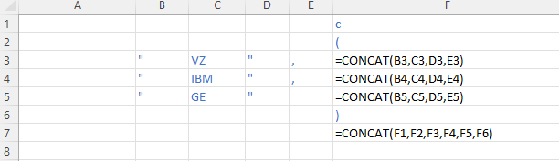

The result should look like

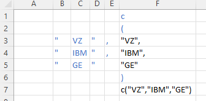

Copy the result in F7.

Step 2: Within R, name your vector and then paste your XLS vector

[figure not shown]

### Load from quandl/NASDAQ

In this example we are loading the adjusted closing price, which is the 11th column of the dataframe. We are loading daily data.

```r
rm(list=ls()) # clear workspace
cat("\014")  # clear console
```

```r
library(Quandl)
quandl_api_key<-read.csv("../data/quandlkey.csv",stringsAsFactors=FALSE)
Quandl.api_key(quandl_api_key)
startd<-"2011-12-30"
endd<-"2013-01-01"
freq<-"daily"
ticker<- c('WIKI/GOOGL.11','WIKI/IBM.11','WIKI/GE.11','WIKI/YHOO.11')
stock_prices = Quandl(ticker,start_date=startd, end_date=endd, collapse=freq,type="zoo")
names(stock_prices)=c('GOOG.Adjusted','IBM.Adjusted','GE.Adjusted','YHOO.Adjusted')
```

### Load from FRED

```r
rm(list=ls()) # clear workspace
cat("\014")  # clear console
```

```r
library(fredr)
fred_api_key<-read.csv("../data/fredkey.csv",stringsAsFactors=FALSE)
fredr_set_key(fred_api_key$Key)
mydata<-fredr(
  series_id = "UNRATE",
  frequency = "m", # monthly
  observation_start = as.Date("1990-01-01"),
  observation_end = as.Date("2000-01-01"),
  units = "pc1" # % Delta 1yr ago
)
```

### Loading from CSV

This assumes that you have a folder called “data” in the directory where your code file is located.

```r
rm(list=ls()) # clear workspace
cat("\014")  # clear console
```

```r
mydata<-read.csv("../data/AAPL.csv")
```

### Loading from TXT

This assumes that you have a folder called “data” in the directory where your code file is located.

```r
rm(list=ls()) # clear workspace
cat("\014")  # clear console
```

```r
mydata<-read.table("../data/AAPL.txt", header = TRUE, sep=" ")
```

### Load from XLS

This assumes that you have a folder called “data” in the directory where your code file is located.

```r
rm(list=ls()) # clear workspace
cat("\014")  # clear console
```

```r
library(readxl)
mydata <- read_excel("../data/AAPL.xlsx")
```

### Save Data

#### Save to CSV

This assumes that you have a folder called “data” in the directory where your code file is located.

```r
rm(list=ls()) # clear workspace
cat("\014")  # clear console
```

```r
mydata<-read.csv("../data/AAPL.csv")
write.csv(mydata, "../data/AAPL_data.csv",row.names = TRUE)
```

#### Save to XLS

This assumes that you have a folder called “data” in the directory where your code file is located.

```r
rm(list=ls()) # clear workspace
cat("\014")  # clear console
```

```r
library(writexl)
library(readxl)
mydata <- read_excel("../data/AAPL.xlsx")
write_xlsx(mydata, '../data/SaveAPPLData.xlsx')
```

### Load SP500 Tickers

```r
rm(list=ls()) # clear workspace
cat("\014")  # clear console
```

```r
# prepare library
library(rvest) # crawl data from html
# fetch S&P ticker list from wiki
url <- "https://en.wikipedia.org/wiki/List_of_S%26P_500_companies"
SP500 <- url %>%
  xml2::read_html() %>%
  html_nodes(xpath='//*[@id="mw-content-text"]/div/table[1]') %>%
  html_table()
SP500 <- SP500[[1]]
SP500_Tickers <- SP500$Symbol
```

### Load DJIA Tickers

```r
rm(list=ls()) # clear workspace
cat("\014")  # clear console
```

```r
# prepare library
library(rvest) # crawl data from html
url <- "https://en.wikipedia.org/wiki/Dow_Jones_Industrial_Average"
DOWJIA <- url %>%
  xml2::read_html() %>%
  html_nodes(xpath='//*[@id="constituents"]') %>%
  html_table()
DOWJIA <- DOWJIA[[1]]
DOWJIA_Tickers <- DOWJIA$Symbol
```

### Load Fama-French 3 Factors

```r
rm(list=ls()) # clear workspace
cat("\014")  # clear console
```

```r
library(tidyverse)
library(xts)
# Load factor data from Ken French website via FTP
# create temp_file to store the file
temp <- tempfile()
# download the file
filename = c('F-F_Research_Data_Factors_CSV.zip')
path = c('https://mba.tuck.dartmouth.edu/pages/faculty/ken.french/ftp/')
todownload = paste0(path,filename)
download.file(todownload, temp)
# unzip the file, to extract the data
#ff_factors_raw_data <- unzip(temp, exdir = here("data"))
ff_factors_raw_data <- unzip(temp)
# read the contents read_csv and extract the desired dates
Factors <- read_csv(ff_factors_raw_data, skip = 3) %>%
  rename("Date" = "...1") %>%
  mutate_all(as.numeric) %>%
  filter(Date > 196301) %>%
  na.omit()

# Format the Factor data frame
FFdate<-as.Date(paste0(as.character(Factors$Date), '01'), format='%Y%m%d')
FFdata<-log(select(Factors, -Date)/100+1) #recall: r=ln(1+R)
FFxts<-xts(FFdata,order.by=FFdate)
# print the first several rows
head(FFxts)
```

```
##                  Mkt-RF          SMB          HML          RF
## 1963-02-01 -0.024087796  0.004589452  0.021761492 0.002297359
## 1963-03-01  0.030335200 -0.025112701  0.018821754 0.002297359
## 1963-04-01  0.044112575 -0.013591954  0.009950331 0.002496880
## 1963-05-01  0.017446914  0.010643160  0.025765208 0.002397125
## 1963-06-01 -0.020202707 -0.002904213  0.007670506 0.002297359
## 1963-07-01 -0.003907625 -0.005314095 -0.008939842 0.002696362
```

### Load Fama-French 5 Factors

```r
rm(list=ls()) # clear workspace
cat("\014")  # clear console
```

```r
library(tidyverse)
library(xts)
# Load factor data from Ken French website via FTP
# create temp_file to store the file
temp <- tempfile()
# download the file
filename = c('F-F_Research_Data_5_Factors_2x3_CSV.zip')
path = c('https://mba.tuck.dartmouth.edu/pages/faculty/ken.french/ftp/')
todownload = paste0(path,filename)
download.file(todownload, temp)
# unzip the file, to extract the data
#ff_factors_raw_data <- unzip(temp, exdir = here("data"))
ff_factors_raw_data <- unzip(temp)
# read the contents read_csv and extract the desired dates
Factors <- read_csv(ff_factors_raw_data, skip = 3) %>%
  rename("Date" = "...1") %>%
  mutate_all(as.numeric) %>%
  filter(Date > 196301) %>%
  na.omit()

# Format the Factor data frame
FFdate<-as.Date(paste0(as.character(Factors$Date), '01'), format='%Y%m%d')
FFdata<-log(select(Factors, -Date)/100+1) #recall: r=ln(1+R)
FFxts<-xts(FFdata,order.by=FFdate)
# print the first several rows
head(FFxts)
```

```
##                  Mkt-RF          SMB           HML          RMW          CMA
## 1963-07-01 -0.003907625 -0.004409708 -0.0089398416  0.006776984 -0.012376271
## 1963-08-01  0.049456609 -0.007528266  0.0166604409  0.003593536 -0.003405793
## 1963-09-01 -0.015824550 -0.005515181  0.0007996802 -0.007125325  0.002895803
## 1963-10-01  0.024985253 -0.013794711 -0.0014009809  0.027615167 -0.020406810
## 1963-11-01 -0.008536331 -0.008939842  0.0179381451 -0.005113049  0.022837234
## 1963-12-01  0.018134570 -0.020917248 -0.0008003202  0.000299955 -0.000400080
##                     RF
## 1963-07-01 0.002696362
## 1963-08-01 0.002496880
## 1963-09-01 0.002696362
## 1963-10-01 0.002895803
## 1963-11-01 0.002696362
## 1963-12-01 0.002895803
```

### Load French 49 Industries

```r
rm(list=ls()) # clear workspace
cat("\014")  # clear console
```

```r
library(tidyverse)
library(xts)
# Load factor data from Ken French website via FTP
# create temp_file to store the file
temp <- tempfile()
# download the file
filename = c('49_Industry_Portfolios_CSV.zip')
path = c('https://mba.tuck.dartmouth.edu/pages/faculty/ken.french/ftp/')
todownload = paste0(path,filename)
download.file(todownload, temp)
# unzip the file, to extract the data
ff_industries_raw_data <- unzip(temp)
# read the contents read_csv and extract the desired dates
Industries <- read_csv(ff_industries_raw_data, skip = 11) %>%
  rename("Date" = "...1") %>%
  mutate_all(as.numeric) %>%
  filter(Date > 196301) %>%
  na.omit()

# Format the Factor data frame
FFdate<-as.Date(paste0(as.character(Industries$Date), '01'), format='%Y%m%d')
FFdata<-log(select(Industries, -Date)/100+1) #recall: r=ln(1+R)
FFxts<-xts(FFdata,order.by=FFdate)
# print the first several rows
head(FFxts)
```

```
##                  Agric         Food     Soda          Beer       Smoke
## 1963-02-01 -0.06006853 -0.026652031 -9.21034 -0.0518197487 -0.03417745
## 1963-02-01 -0.05752319 -0.004811557 -9.21034 -0.0293258294 -0.02829660
## 1963-02-01  0.01980263  0.482426149  0.00000  0.1043600153  0.11332869
## 1963-02-01  1.22829462  1.210392156 -9.21034  0.8182809113  1.38404183
## 1963-03-01 -0.01969263  0.018330957 -9.21034  0.0450689634  0.07455073
## 1963-03-01 -0.01979463  0.014790085 -9.21034  0.0009995003  0.04258045
##                   Toys         Fun        Books       Hshld       Clths
## 1963-02-01 -0.10236501 -0.03676772 -0.020815140 -0.03303985 -0.03438443
## 1963-02-01 -0.09453048 -0.02326863 -0.033143219 -0.03624913 -0.02613866
## 1963-02-01  0.04879016  0.11332869  0.095310180  0.27002714  0.19062036
## 1963-02-01  0.97009687  0.52579305  0.517125736  1.05997541  0.39971528
## 1963-03-01 -0.01867327  0.03758476 -0.003506139  0.03922071  0.01419872
## 1963-03-01  0.05458288  0.03796993 -0.001200721  0.02078254  0.01163208
##                Hlth         MedEq       Drugs       Chems        Rubbr
## 1963-02-01 -9.21034  0.0153811020 -0.02901695 -0.03926071 -0.006923915
## 1963-02-01 -9.21034 -0.0107576567 -0.02357574 -0.01755316 -0.015824550
## 1963-02-01  0.00000  0.0392207132  0.17395331  0.37843644  0.067658648
## 1963-02-01 -9.21034  0.8751770281  1.66013103  1.95996802  0.237835100
## 1963-03-01 -9.21034  0.0006997551  0.01252128  0.03584965  0.036042591
## 1963-03-01 -9.21034 -0.0058168853  0.01646373  0.03662118  0.022739487
##                   Txtls        BldMt        Cnstr        Steel    FabPr
## 1963-02-01  0.006478966 -0.006018072 -0.027371197 -0.021530119 -9.21034
## 1963-02-01 -0.008435479 -0.008334637 -0.026036015 -0.003907625 -9.21034
## 1963-02-01  0.215111380  0.536493371  0.076961041  0.553885113  0.00000
## 1963-02-01  0.405465108  0.838502148  0.501441732  1.121221432 -9.21034
## 1963-03-01  0.008265744  0.035367144  0.005286004  0.022152805 -9.21034
## 1963-03-01  0.014198719  0.030626194 -0.003907625  0.020390690 -9.21034
##                   Mach       ElcEq        Autos        Aero        Ships
## 1963-02-01 -0.02634398 -0.06571254 -0.029737818 -0.01765494 0.0129162253
## 1963-02-01 -0.01714616 -0.04040541 -0.004811557 -0.01359195 0.0005998201
## 1963-02-01  0.55388511  0.42526774  0.350656872  0.22314355 0.1397619424
## 1963-02-01  0.71798612  1.35472629  2.081202490  0.89824895 0.6159421097
## 1963-03-01  0.02858746  0.01380428  0.065974989 -0.01551981 0.0497420919
## 1963-03-01  0.03556018 -0.01694272  0.025570276 -0.01806214 0.0412379080
##                Guns     Gold        Mines         Coal         Oil         Util
## 1963-02-01 -9.21034 -9.21034 -0.017756722 -0.004409708 -0.01338924 -0.014910613
## 1963-02-01 -9.21034 -9.21034 -0.021019367 -0.018163971 -0.01836766 -0.006521217
## 1963-02-01  0.00000  0.00000  0.157003749  0.076961041  0.35767444  0.708035793
## 1963-02-01 -9.21034 -9.21034  0.530157552  0.814568036  2.51850260  1.652382453
```

[output cut: 15 more lines]

```
## 1963-03-01 -0.01308524 0.02917038  0.033724869 0.034691240  0.0078689584
##                   Rtail       Meals        Banks        Insur        RlEst
## 1963-02-01 -0.005515181 -0.03811732  0.004788517 -0.037598030 -0.056464537
## 1963-02-01 -0.025830760 -0.03874083 -0.010454458 -0.037598030 -0.059537713
## 1963-02-01  0.536493371  0.08617770  0.207014169  0.009950331  0.019802627
## 1963-02-01  1.147973718  0.29877037  1.031831255  2.190166394  0.310274921
## 1963-03-01  0.021467907 -0.05890111  0.019410394  0.020586634  0.003394233
## 1963-03-01  0.008265744 -0.03056231  0.049742092  0.020586634  0.000299955
##                     Fin       Other
## 1963-02-01 -0.003606496 0.006578315
## 1963-02-01 -0.025215249 0.012323750
## 1963-02-01  0.165514438 0.048790164
## 1963-02-01  0.924377942 0.699924165
## 1963-03-01  0.029073247 0.057136191
## 1963-03-01  0.018527305 0.002397125
```

### Load US Recession Dates

```r
rm(list=ls()) # clear workspace
cat("\014")  # clear console
```

```r
library(quantmod)
getSymbols("USREC",src="FRED")
```

```
## [1] "USREC"
```

## Plotting Prices

### Price Chart

```r
rm(list=ls()) # clear workspace
cat("\014")  # clear console
```

```r
library("tidyquant")
ticker = 'MSFT' # asset ticker
start_date = '2017-01-01' # data start date
end_date = '2021-03-01' # data end date
data_src = 'yahoo' # data source
getSymbols(ticker,from = start_date,to = end_date, src=data_src)
```

```
## [1] "MSFT"
```

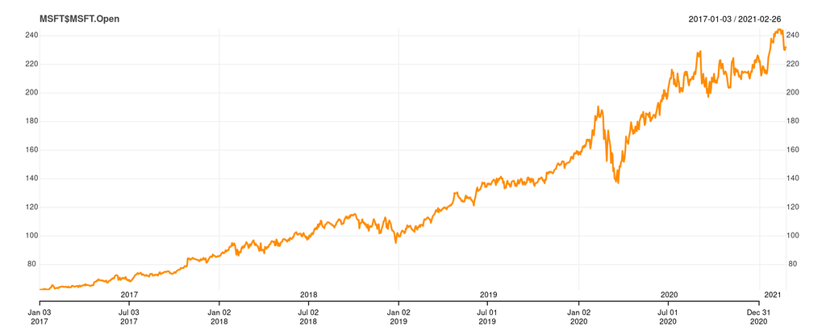

```r
chart_Series(x=MSFT$MSFT.Open)
```

### Candlestick Chart

```r
rm(list=ls()) # clear workspace
cat("\014")  # clear console
```

```r
library("tidyquant")
ticker = 'MSFT' # asset ticker
start_date = '2017-01-01' # data start date
end_date = '2021-03-01' # data end date
data_src = 'yahoo' # data source
getSymbols(ticker,from = start_date,to = end_date, src=data_src)
```

```
## [1] "MSFT"
```

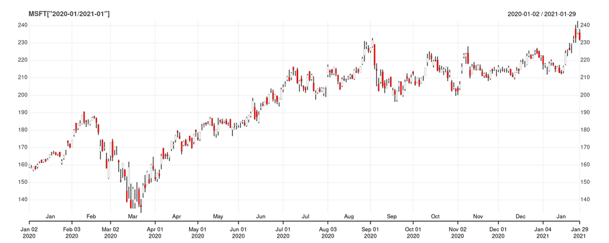

```r
chart_Series(x=MSFT['2020-01/2021-01'])
```

### Price Chart w/ Volume & Bands

```r
rm(list=ls()) # clear workspace
cat("\014")  # clear console
```

```r
library("tidyquant")
ticker = 'MSFT' # asset ticker
start_date = '2017-01-01' # data start date
end_date = '2021-03-01' # data end date
data_src = 'yahoo' # data source
getSymbols(ticker,from = start_date,to = end_date, src=data_src)
```

```
## [1] "MSFT"
```

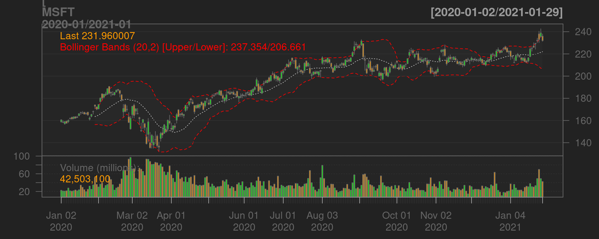

```r
chartSeries(x=MSFT['2020-01/2021-01'],TA=c(addVo(),addBBands()))
```

### Price Chart with Multiple Tickers

can probably use the quandl api to make this easier

```r
rm(list=ls()) # clear workspace
cat("\014")  # clear console
```

```r
library(quantmod)
Tickers<-c('F','GE','CAT')
startd = "2015-01-01"
endd = "2021-04-30"
# pull data from yahoo/FRED
getSymbols(Tickers,from=startd,to=endd,src='yahoo')
```

```
## [1] "F"   "GE"  "CAT"
```

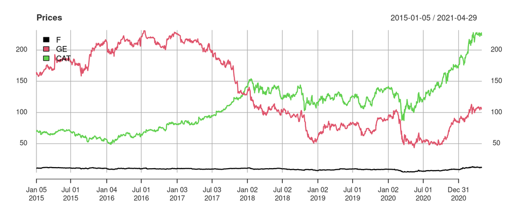

```r
Prices = do.call(merge,lapply(Tickers, function(x) Ad(get(x))))
Prices = na.omit(Prices[-1,])
colnames(Prices)<-Tickers
plot(Prices,legend.loc = 'topleft')
```

### Indexed Price Chart

```r
rm(list=ls()) # clear workspace
cat("\014")  # clear console
```

```r
library("tidyquant")
ticker = c('MSFT','IBM') # asset ticker
start_date = '2017-01-01' # data start date
end_date = '2021-03-01' # data end date
data_src = 'yahoo' # data source
getSymbols(ticker,from = start_date,to = end_date, src=data_src)
```

```
## [1] "MSFT" "IBM"
```

```r
Prices = do.call(merge,lapply(ticker, function(x) Ad(get(x))))
Prices = na.omit(Prices[-1,])
Returns = do.call(merge,lapply(ticker, function(x)
        periodReturn(Ad(get(x)),period='daily',type='arithmetic')))
Returns = na.omit(Returns[-1,])
colnames(Returns)<-ticker
StartingEquity=1
GrossReturns <- Returns+1
GrossReturns[1,]<-StartingEquity
GrossReturns<-cumprod(GrossReturns)
head(GrossReturns)
```

```
##                MSFT       IBM
## 2017-01-04 1.000000 1.0000000
## 2017-01-05 1.000000 0.9966915
## 2017-01-06 1.008668 1.0015953
## 2017-01-09 1.005457 0.9904882
## 2017-01-10 1.005136 0.9779039
## 2017-01-11 1.014286 0.9910791
```

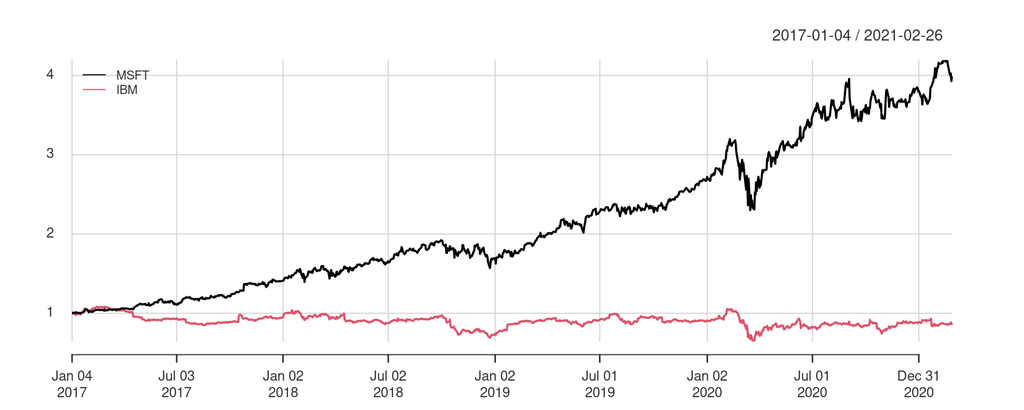

```r
chart.TimeSeries(GrossReturns,legend.loc = 'topleft')
```

### Multi-Asset Indexed Price Chart

```r
rm(list=ls()) # clear workspace
cat("\014")  # clear console
```

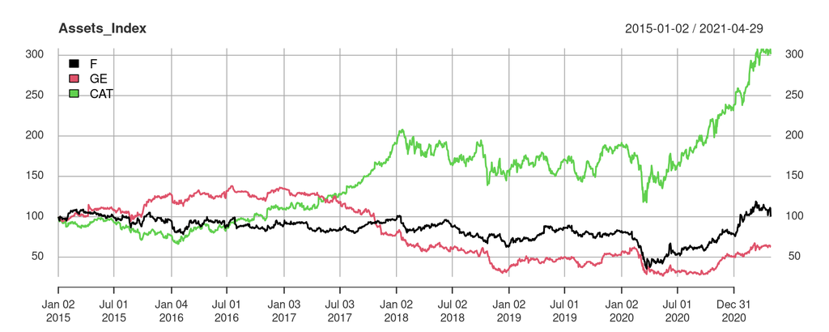

```r
library(quantmod)
Tickers<-c('F','GE','CAT')
startd = "2015-01-01"
endd = "2021-04-30"
TickersReturned<-getSymbols(Tickers,from=startd,to=endd,src='yahoo')
Prices = as.xts(data.frame(F=F$F.Adjusted,GE=GE$GE.Adjusted, CAT=CAT$CAT.Adjusted))
colnames(Prices)<-Tickers
Assets_begPrice=as.numeric(head(Prices,n=1))
Assets_GrossCumRet<- Prices/rep((Assets_begPrice), each = nrow(Prices))
Assets_Index<-100*Assets_GrossCumRet
plot(Assets_Index,legend.loc = 'topleft')
```

### Price Chart with Drawdowns

```r
rm(list=ls()) # clear workspace
cat("\014")  # clear console
```

```r
library("tidyquant")
ticker = 'MSFT' # asset ticker
start_date = '2017-01-01' # data start date
end_date = '2021-03-01' # data end date
data_src = 'yahoo' # data source
getSymbols(ticker,from = start_date,to = end_date, src=data_src)
```

```
## [1] "MSFT"
```

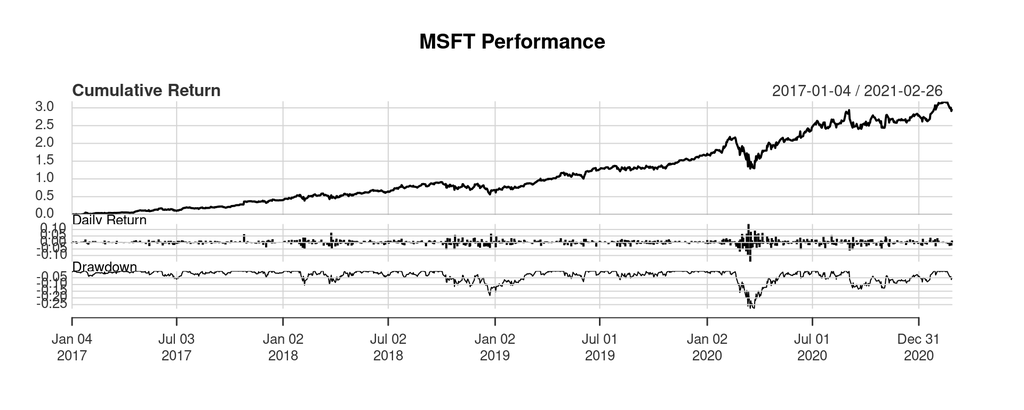

```r
Returns = do.call(merge,lapply(ticker, function(x)
        periodReturn(Ad(get(x)),period='daily',type='arithmetic')))
Returns = na.omit(Returns[-1,])
colnames(Returns)<-ticker
charts.PerformanceSummary(Returns)
```

### Recession Shading

Reference: https://rpubs.com/FSl/609471

```r
rm(list=ls()) # clear workspace
cat("\014")  # clear console
```

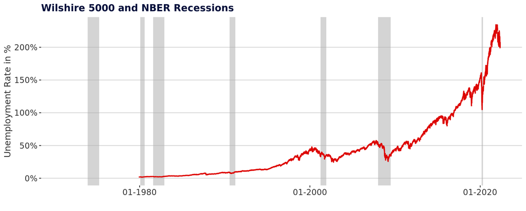

```r
library(fredr)
fred_api_key<-read.csv("../data/fredkey.csv",stringsAsFactors=FALSE)
fredr_set_key(fred_api_key$Key)
fred_data<-fredr(series_id = "WILL5000INDFC",observation_start = as.Date("1971-01-01"))
theme_am<-
function (base_size = 12, base_family = "")
{
  library(ggthemes)
  library(scales)
  library(extrafont)
  theme_hc(base_size = base_size, base_family = base_family) %+replace%
    theme(
      axis.text.x = element_text(color = "grey20", size = 11,family="Calibri Light"),
      axis.text.y = element_text(color = "grey20", size = 11,family="Calibri Light"),
      axis.title.x = element_text(color = "grey20", size = 12,family="Calibri Light"),
      axis.title.y = element_text(color = "grey20", size = 12,family="Calibri Light"),
      plot.title = element_text(color="#04103b", size=13, face="bold",family="Calibri Light"),
      legend.text = element_text(color = "grey20", size = 12,family="Calibri Light")
    )
}
add_rec_shade<-function(st_date,ed_date,shade_color="darkgray")
{
  library(fredr)
  library(ecm)
  library(ggplot2)
  #fredr_set_key("insert_your_api_key")

  #st_date<-as.Date("2001-06-01")
  #ed_date<-as.Date(Sys.Date())

  recession<-fredr(series_id = "USRECD",observation_start = as.Date(st_date),observation_end = as.Date(ed_date))

  recession$diff<-recession$value-lagpad(recession$value,k=1)
  recession<-recession[!is.na(recession$diff),]
  recession.start<-recession[recession$diff==1,]$date
  recession.end<-recession[recession$diff==(-1),]$date

  if(length(recession.start)>length(recession.end))
  {recession.end<-c(recession.end,Sys.Date())}
  if(length(recession.end)>length(recession.start))
  {recession.start<-c(min(recession$date),recession.start)}

  recs<-as.data.frame(cbind(recession.start,recession.end))
  recs$recession.start<-as.Date(as.numeric(recs$recession.start),origin=as.Date("1970-01-01"))
  recs$recession.end<-as.Date(recs$recession.end,origin=as.Date("1970-01-01"))
  if(nrow(recs)>0)
  {
    rec_shade<-geom_rect(data=recs, inherit.aes=F,
                         aes(xmin=recession.start, xmax=recession.end, ymin=-Inf, ymax=+Inf),
                         fill=shade_color, alpha=0.5)
    return(rec_shade)
  }
}
library(extrafont)
## Registering fonts with R
library(ggplot2)

my_plot<-
  ggplot(fred_data, aes(x=date)) +
  #Add recession shading here
  #******************************************************************
  add_rec_shade(min(fred_data$date),max(fred_data$date))+
  #******************************************************************
  geom_line(aes(y=value/100),size = 0.8,color="#dd0400") +
  scale_y_continuous(name="Unemployment Rate in %",labels = scales::percent_format(accuracy = 1)) +
  theme_am()+
  scale_x_date(labels = date_format("%m-%Y"))+
  theme(plot.title = element_text(color="#04103b", size=13, face="bold",family="Calibri Light"))+
  labs(title="Wilshire 5000 and NBER Recessions",x ="")

my_plot
```

## Computing Returns

### Compute Lag

```r
rm(list=ls()) # clear workspace
cat("\014")  # clear console
```

```r
library(tidyquant)
ticker = 'AAPL' # asset ticker
start_date = '2017-01-01' # data start date
end_date = '2021-02-01' # data end date
data_src = 'yahoo' # data source
getSymbols(ticker,from = start_date, to = end_date, src=data_src)
```

```
## [1] "AAPL"
```

```r
LagAdjClose = lag.xts(AAPL$AAPL.Adjusted,k=1)
head(LagAdjClose)
```

```
##            AAPL.Adjusted
## 2017-01-03            NA
## 2017-01-04      27.25765
## 2017-01-05      27.22714
## 2017-01-06      27.36559
## 2017-01-09      27.67067
## 2017-01-10      27.92412
```

### Compute Many Lags

```r
rm(list=ls()) # clear workspace
cat("\014")  # clear console
```

```r
library(tidyquant)
ticker = 'AAPL' # asset ticker
start_date = '2017-01-01' # data start date
end_date = '2021-02-01' # data end date
data_src = 'yahoo' # data source
getSymbols(ticker,from = start_date, to = end_date, src=data_src)
```

```
## [1] "AAPL"
```

```r
LagAdjClose = lag.xts(AAPL$AAPL.Adjusted,k=1:2)
head(LagAdjClose)
```

```
##            AAPL.Adjusted AAPL.Adjusted.1
## 2017-01-03            NA              NA
## 2017-01-04      27.25764              NA
## 2017-01-05      27.22713        27.25764
## 2017-01-06      27.36560        27.22713
## 2017-01-09      27.67067        27.36560
## 2017-01-10      27.92412        27.67067
```

### Simple Daily Returns (v1)

```r
rm(list=ls()) # clear workspace
cat("\014")  # clear console
```

```r
library(tidyquant)
ticker = 'AAPL' # asset ticker
start_date = '2017-01-01' # data start date
end_date = '2021-02-01' # data end date
data_src = 'yahoo' # data source
getSymbols(ticker,from = start_date, to = end_date, src=data_src)
```

```
## [1] "AAPL"
```

```r
Return_AAPL = AAPL$AAPL.Adjusted/lag.xts(AAPL$AAPL.Adjusted,k=1) - 1 # use lag.xts to obtain the lag for xts data
Return_AAPL = na.omit(Return_AAPL) #remove NA value
```

### Simple Daily Returns (v2)

```r
rm(list=ls()) # clear workspace
cat("\014")  # clear console
```

```r
library(tidyquant)
ticker = 'AAPL' # asset ticker
start_date = '2017-01-01' # data start date
end_date = '2021-02-01' # data end date
data_src = 'yahoo' # data source
getSymbols(ticker,from = start_date, to = end_date, src=data_src)
```

```
## [1] "AAPL"
```

```r
price_diff = diff(x = AAPL$AAPL.Adjusted,differences = 1) # calculate one period difference
price_diff = na.omit(price_diff) #remove NA value
dim(price_diff) # Look at the size of price_diff
```

```
## [1] 1025    1
```

```r
price_t = AAPL$AAPL.Adjusted[-length(AAPL$AAPL.Adjusted)] # remove the last observation
## calculate return via R_t = (P_t-P_{t-1})/P_{t-1}
Return_AAPL2 = price_diff/as.numeric(price_t)
```

### Simple Weekly Returns

```r
rm(list=ls()) # clear workspace
cat("\014")  # clear console
```

```r
library("tidyquant")
ticker = 'MSFT' # asset ticker
start_date = '2017-01-01' # data start date
end_date = '2021-03-01' # data end date
data_src = 'yahoo' # data source
getSymbols(ticker,from = start_date,to = end_date, src=data_src)
```

```
## [1] "MSFT"
```

```r
Returns = do.call(merge,lapply(ticker, function(x)
        periodReturn(Ad(get(x)),period='weekly',type='arithmetic')))
head(Returns)
```

```
##            weekly.returns
## 2017-01-06   0.0041547774
## 2017-01-13  -0.0022277717
## 2017-01-20   0.0006377972
## 2017-01-27   0.0484542310
## 2017-02-03  -0.0319247856
## 2017-02-10   0.0050252768
```

### Simple Rolling Returns

```r
rm(list=ls()) # clear workspace
cat("\014")  # clear console
```

```r
library("tidyquant")
ticker = 'MSFT' # asset ticker
start_date = '2017-01-01' # data start date
end_date = '2021-03-01' # data end date
data_src = 'yahoo' # data source
getSymbols(ticker,from = start_date,to = end_date, src=data_src)
```

```
## [1] "MSFT"
```

```r
Prices = do.call(merge,lapply(ticker, function(x) Ad(get(x))))
Prices = na.omit(Prices[-1,])
T=dim(Prices)[1]
FiveDayRet = Prices$MSFT.Adjusted/lag.xts(Prices$MSFT.Adjusted,k=5) - 1
head(FiveDayRet,n=10)
```

```
##            MSFT.Adjusted
## 2017-01-04            NA
## 2017-01-05            NA
## 2017-01-06            NA
## 2017-01-09            NA
## 2017-01-10            NA
## 2017-01-11   0.014285695
## 2017-01-12   0.004975845
## 2017-01-13  -0.002227771
## 2017-01-17  -0.001755954
## 2017-01-18  -0.001916267
```

### Simple Total Returns

```r
rm(list=ls()) # clear workspace
cat("\014")  # clear console
```

```r
library("tidyquant")
ticker = 'MSFT' # asset ticker
start_date = '2017-01-01' # data start date
end_date = '2021-03-01' # data end date
data_src = 'yahoo' # data source
getSymbols(ticker,from = start_date,to = end_date, src=data_src)
```

```
## [1] "MSFT"
```

```r
Prices = do.call(merge,lapply(ticker, function(x) Ad(get(x))))
Prices = na.omit(Prices[-1,])
TotalReturn  = as.numeric(head(Prices,n=1))/as.numeric(tail(Prices,n=1))-1
TotalReturn
```

```
## [1] -0.7492189
```

### Log Daily Returns (v1)

```r
rm(list=ls()) # clear workspace
cat("\014")  # clear console
```

```r
library("tidyquant")
ticker = 'MSFT' # asset ticker
start_date = '2017-01-01' # data start date
end_date = '2021-03-01' # data end date
data_src = 'yahoo' # data source
getSymbols(ticker,from = start_date,to = end_date, src=data_src)
```

```
## [1] "MSFT"
```

```r
Returns = periodReturn(MSFT$MSFT.Adjusted,period = 'daily',type = 'log')
head(Returns)
```

```
##            daily.returns
## 2017-01-03   0.000000000
## 2017-01-04  -0.004484180
## 2017-01-05   0.000000000
## 2017-01-06   0.008630401
## 2017-01-09  -0.003187986
## 2017-01-10  -0.000319212
```

### Log Daily Returns (v2)

My preferred approach since I can “see” what is happening.

```r
rm(list=ls()) # clear workspace
cat("\014")  # clear console
```

```r
library("tidyquant")
ticker = 'MSFT' # asset ticker
start_date = '2017-01-01' # data start date
end_date = '2021-03-01' # data end date
data_src = 'yahoo' # data source
getSymbols(ticker,from = start_date,to = end_date, src=data_src)
```

```
## [1] "MSFT"
```

```r
Returns = log(MSFT$MSFT.Adjusted/lag.xts(MSFT$MSFT.Adjusted,k=1))
head(Returns)
```

```
##            MSFT.Adjusted
## 2017-01-03            NA
## 2017-01-04 -0.0044843693
## 2017-01-05  0.0000000000
## 2017-01-06  0.0086303497
## 2017-01-09 -0.0031875910
## 2017-01-10 -0.0003196939
```

### Currency Adjust. Ret. (v1)

```r
rm(list=ls()) # clear workspace
cat("\014")  # clear console
```

```r
library(tidyquant)
ticker = 'AAPL' # asset ticker
start_date = '2014-09-25' # data start date
end_date = '2015-02-01' # data end date
data_src = 'yahoo' # data source
freq = "daily" # data frequency
getSymbols(ticker,from = start_date,
           to = end_date, src=data_src, periodicity = freq)
```

```
## [1] "AAPL"
```

```r
ticker = 'DEXUSEU' # ticker for "U.S. / Euro Foreign Exchange Rate", can be found from FRED website
data_src = 'FRED' # data source
getSymbols(ticker, src=data_src)
```

```
## [1] "DEXUSEU"
```

```r
DEXUSEU = na.approx(DEXUSEU) # fill in missing values with mean of previous and next obs.
### merge exchange rate and AAPL price
dat=merge(AAPL$AAPL.Adjusted, DEXUSEU, join='left')
### calculate adjusted price: covert USD price to EUR price(our original data price is USD based)
dat$Price_EUR = dat$AAPL.Adjusted/dat$DEXUSEU
head(dat)
```

```
##            AAPL.Adjusted DEXUSEU Price_EUR
## 2014-09-25      21.99609  1.2748  17.25454
## 2014-09-26      22.64337  1.2686  17.84910
## 2014-09-29      22.49952  1.2703  17.71198
## 2014-09-30      22.64337  1.2628  17.93108
## 2014-10-01      22.29051  1.2618  17.66564
## 2014-10-02      22.45233  1.2670  17.72086
```

```r
### calculate USD based return
price_t = dat$AAPL.Adjusted[-length(dat$AAPL.Adjusted)] # remove the last observation
price_diff = diff(x = dat$AAPL.Adjusted,differences = 1) # calculate one period difference
price_diff = na.omit(price_diff) # remove NA value
Return_AAPL_USD = price_diff/as.numeric(price_t)
names(Return_AAPL_USD)="USDReturn"

### calculate exchange rate return
FX_t = dat$DEXUSEU[-length(dat$DEXUSEU)] # remove the last observation
FX_diff = diff(x = dat$DEXUSEU,differences = 1) # calculate one period difference
FX_diff = na.omit(FX_diff) # remove NA value
Return_FX = FX_diff/as.numeric(FX_t)
names(Return_FX)="ReturnFX"

### calculate Euro Based Investor's return
# method 1: 1+R_t(USD)=(1+R_t(FX))(1+R_t(EUR))
Return_AAPL_EUR = (1+Return_AAPL_USD)/(1+Return_FX)-1
head(Return_AAPL_EUR)
```

```
##               USDReturn
## 2014-09-26  0.034458332
## 2014-09-29 -0.007682397
## 2014-09-30  0.012370400
## 2014-10-01 -0.014803378
## 2014-10-02  0.003125883
## 2014-10-03  0.009385974
```

### Currency Adjust. Ret. (v2)

```r
rm(list=ls()) # clear workspace
cat("\014")  # clear console
```

```r
library(tidyquant)
ticker = 'AAPL' # asset ticker
start_date = '2014-09-25' # data start date
end_date = '2015-02-01' # data end date
data_src = 'yahoo' # data source
freq = "daily" # data frequency
getSymbols(ticker,from = start_date,
           to = end_date, src=data_src, periodicity = freq)
```

```
## [1] "AAPL"
```

```r
ticker = 'DEXUSEU' # ticker for "U.S. / Euro Foreign Exchange Rate", can be found from FRED website
data_src = 'FRED' # data source
getSymbols(ticker, src=data_src)
```

```
## [1] "DEXUSEU"
```

```r
DEXUSEU = na.approx(DEXUSEU) # fill in missing values with mean of previous and next obs.
### merge exchange rate and AAPL price
dat=merge(AAPL$AAPL.Adjusted, DEXUSEU, join='left')
### calculate adjusted price: covert USD price to EUR price(our original data price is USD based)
dat$Price_EUR = dat$AAPL.Adjusted/dat$DEXUSEU
head(dat)
```

```
##            AAPL.Adjusted DEXUSEU Price_EUR
## 2014-09-25      21.99609  1.2748  17.25454
## 2014-09-26      22.64336  1.2686  17.84910
## 2014-09-29      22.49953  1.2703  17.71198
## 2014-09-30      22.64336  1.2628  17.93108
## 2014-10-01      22.29051  1.2618  17.66564
## 2014-10-02      22.45233  1.2670  17.72086
```

```r
price_tEUR = dat$Price_EUR[-length(dat$Price_EUR)] # remove the last observation
price_diffEUR = diff(x = dat$Price_EUR,differences = 1) # calculate one period difference
price_diffEUR = na.omit(price_diffEUR) # remove NA value
Return_AAPL_EUR_method2 = price_diffEUR/as.numeric(price_tEUR)
head(Return_AAPL_EUR_method2)
```

```
##               Price_EUR
## 2014-09-26  0.034457684
## 2014-09-29 -0.007681870
## 2014-09-30  0.012369862
## 2014-10-01 -0.014802853
## 2014-10-02  0.003125703
## 2014-10-03  0.009386064
```

### Inflation Adjust. Ret. (v1)

```r
rm(list=ls()) # clear workspace
cat("\014")  # clear console
```

```r
library(quantmod)

ticker = 'AAPL' # asset ticker
start_date = '2005-01-01' # data start date
end_date = '2021-02-01' # data end date
data_src = 'yahoo' # data source
freq = "monthly" # data frequency
# load data using `getSymbols`
getSymbols(ticker,from = start_date,
           to = end_date, src=data_src, periodicity = freq)
```

```
## [1] "AAPL"
```

```r
### load CPI data from FRED
# set parameters
ticker = 'CPIAUCSL' # ticker for "Consumer Price Index for All Urban Consumers: All Items", can be found from FRED website
data_src = 'FRED' # data source
# load data using `getSymbols`
getSymbols(ticker, src=data_src)
```

```
## [1] "CPIAUCSL"
```

```r
### merge CPI data and AAPL price
dat=merge(AAPL$AAPL.Adjusted, CPIAUCSL, join='left')
### calculate adjusted price
# calculate deflator (with deflator on 2017-01 equal to one)
dat$Deflator = dat$CPIAUCSL/as.numeric(dat$CPIAUCSL['2017-01',])
# calculate adjusted price
dat$RealPrice = dat$AAPL.Adjusted/dat$Deflator
head(dat)
```

```
##            AAPL.Adjusted CPIAUCSL  Deflator RealPrice
## 2005-01-01      1.174122    191.6 0.7864772  1.492888
## 2005-02-01      1.369861    192.4 0.7897610  1.734526
## 2005-03-01      1.272450    193.1 0.7926344  1.605343
## 2005-04-01      1.101141    193.7 0.7950972  1.384914
## 2005-05-01      1.214125    193.6 0.7946868  1.527803
## 2005-06-01      1.124043    193.7 0.7950972  1.413718
```

```r
### method 1: calculate real returns using real price
price_t_real = dat$RealPrice[-length(dat$RealPrice)] # remove the last observation
price_diff_real = diff(x = dat$RealPrice,differences = 1) # calculate one period difference
price_diff_real = na.omit(price_diff_real) #remove NA value
realReturn_AAPL= price_diff_real/as.numeric(price_t_real)
names(realReturn_AAPL)="RealReturn_method1"
# print the first several rows
head(realReturn_AAPL)
```

```
##            RealReturn_method1
## 2005-02-01         0.16185977
## 2005-03-01        -0.07447742
## 2005-04-01        -0.13730981
## 2005-05-01         0.10317582
## 2005-06-01        -0.07467295
## 2005-07-01         0.15151847
```

### Inflation Adjust. Ret. (v2)

```r
rm(list=ls()) # clear workspace
cat("\014")  # clear console
```

```r
library(quantmod)

ticker = 'AAPL' # asset ticker
start_date = '2005-01-01' # data start date
end_date = '2021-02-01' # data end date
data_src = 'yahoo' # data source
freq = "monthly" # data frequency
# load data using `getSymbols`
getSymbols(ticker,from = start_date,
           to = end_date, src=data_src, periodicity = freq)
```

```
## [1] "AAPL"
```

```r
### load CPI data from FRED
# set parameters
ticker = 'CPIAUCSL' # ticker for "Consumer Price Index for All Urban Consumers: All Items", can be found from FRED website
data_src = 'FRED' # data source
# load data using `getSymbols`
getSymbols(ticker, src=data_src)
```

```
## [1] "CPIAUCSL"
```

```r
### merge CPI data and AAPL price
dat=merge(AAPL$AAPL.Adjusted, CPIAUCSL, join='left')
### method 2: calculate real returns by adjusting nominal returns
# calculate norminal returns
price_t = dat$AAPL.Adjusted[-length(dat$AAPL.Adjusted)] # remove the last observation
price_diff = diff(x = dat$AAPL.Adjusted,differences = 1) # calculate one period difference
price_diff = na.omit(price_diff) # remove NA value
Return_AAPL = price_diff/as.numeric(price_t)
names(Return_AAPL)="norminalReturn"

# calculate monthly inflation
CPI_diff = diff(x=dat$CPIAUCSL,differences =1) # calculate one period difference
CPI_diff = na.omit(CPI_diff) # remove NA
monthly_inflation = CPI_diff/as.numeric(dat$CPIAUCSL[-length(dat$CPIAUCSL)])
names(monthly_inflation) = "monthly_inflation"

# adjust nominal return to inflation: (1+R_norminal)=(1+R_real)(1+monthly inflation rate)
realReturn_AAPL_method2 = (1+Return_AAPL)/(1+monthly_inflation)-1
# print the first several rows
head(realReturn_AAPL_method2)
```

```
##            norminalReturn
## 2005-02-01     0.16185878
## 2005-03-01    -0.07447742
## 2005-04-01    -0.13730981
## 2005-05-01     0.10317673
## 2005-06-01    -0.07467372
## 2005-07-01     0.15151847
```

### Annualize Simple Returns

```r
rm(list=ls()) # clear workspace
cat("\014")  # clear console
```

```r
library(quantmod)

ticker = 'AAPL' # asset ticker
start_date = '2005-01-01' # data start date
end_date = '2021-02-01' # data end date
data_src = 'yahoo' # data source
freq = "daily" # data frequency
# load data using `getSymbols`
getSymbols(ticker,from = start_date,
           to = end_date, src=data_src, periodicity = freq)
```

```
## [1] "AAPL"
```

```r
Daily_AAPL = periodReturn(AAPL$AAPL.Adjusted,period = "daily",type = "arithmetic")

Annualized_APPL<-(1+Daily_AAPL)^(250/1)-1
todisplay<-cbind(Daily_AAPL,Annualized_APPL)
head(todisplay)
```

```
##            daily.returns daily.returns.1
## 2005-01-03  0.0000000000    0.000000e+00
## 2005-01-04  0.0102698474    1.186316e+01
## 2005-01-05  0.0087580205    7.846066e+00
## 2005-01-06  0.0007747782    2.136345e-01
## 2005-01-07  0.0728123373    4.275036e+07
## 2005-01-10 -0.0041879390   -6.497763e-01
```

Note: A number like 1.18e+01 can be read as 11.8.  
Note: A number like .01 is 1%, so 11.8 is 1,180%

### Annualize Log Returns

```r
rm(list=ls()) # clear workspace
cat("\014")  # clear console
```

```r
library("tidyquant")
ticker = 'MSFT' # asset ticker
start_date = '2017-01-01' # data start date
end_date = '2021-03-01' # data end date
data_src = 'yahoo' # data source
getSymbols(ticker,from = start_date,to = end_date, src=data_src)
```

```
## [1] "MSFT"
```

```r
Daily_MSFT = log(MSFT$MSFT.Adjusted/lag.xts(MSFT$MSFT.Adjusted,k=1))
Annualized_MSFT = Daily_MSFT*250
todisplay<-cbind(Daily_MSFT,Annualized_MSFT)
head(todisplay)
```

```
##            MSFT.Adjusted MSFT.Adjusted.1
## 2017-01-03            NA              NA
## 2017-01-04 -0.0044843693     -1.12109232
## 2017-01-05  0.0000000000      0.00000000
## 2017-01-06  0.0086302811      2.15757028
## 2017-01-09 -0.0031877977     -0.79694942
## 2017-01-10 -0.0003192809     -0.07982022
```

Note: A number like 1.18e+01 can be read as 11.8.  
Note: A number like .01 is 1%, so 11.8 is 1,180%

### Convert Daily to Weekly

```r
rm(list=ls()) # clear workspace
cat("\014")  # clear console
```

```r
library("tidyquant")
ticker = 'MSFT' # asset ticker
start_date = '2017-01-01' # data start date
end_date = '2021-03-01' # data end date
data_src = 'yahoo' # data source
getSymbols(ticker,from = start_date,to = end_date, src=data_src)
```

```
## [1] "MSFT"
```

```r
MSFT<-MSFT$MSFT.Adjusted
colnames(MSFT)<-ticker
WeeklyPrices<-to.weekly(MSFT)
head(WeeklyPrices)
```

```
##            MSFT.Open MSFT.High MSFT.Low MSFT.Close
## 2017-01-06  58.06546  58.30670 57.80565   58.30670
## 2017-01-13  58.12111  58.63145 58.09330   58.17680
## 2017-01-20  58.01907  58.21392 57.80565   58.21392
## 2017-01-27  58.41804  61.03460 58.41804   61.03460
## 2017-02-03  60.43149  60.43149 58.61288   59.08611
## 2017-02-10  59.04899  59.43868 58.77063   59.38301
```

```r
head(MSFT,n=10)
```

```
##                MSFT
## 2017-01-03 58.06546
## 2017-01-04 57.80565
## 2017-01-05 57.80565
## 2017-01-06 58.30670
## 2017-01-09 58.12111
## 2017-01-10 58.10257
## 2017-01-11 58.63145
## 2017-01-12 58.09330
## 2017-01-13 58.17680
## 2017-01-17 58.01907
```

CAUTION: The suffixes .Open,.High,.Low,.Close are NOT those respective metrics from the HLOCV dataset pulled from yahoo. For instance, .Open is the first day of the week, whereas .High is the highest daily price during the week.

### Fill in Missing Dates

```r
rm(list=ls()) # clear workspace
cat("\014")  # clear console
```

```r
library("tidyquant")
ticker = 'MSFT' # asset ticker
start_date = '2017-01-01' # data start date
end_date = '2021-03-01' # data end date
data_src = 'yahoo' # data source
getSymbols(ticker,from = start_date,to = end_date, src=data_src)
```

```
## [1] "MSFT"
```

```r
# Suppose observations were missing
MSFT$MSFT.Adjusted[c(3:5),]=NA
head(MSFT$MSFT.Adjusted)
```

```
##            MSFT.Adjusted
## 2017-01-03      58.06546
## 2017-01-04      57.80565
## 2017-01-05            NA
## 2017-01-06            NA
## 2017-01-09            NA
## 2017-01-10      58.10257
```

```r
#Fill in with na.approx
FILLED<-na.approx(MSFT$MSFT.Adjusted)
head(FILLED)
```

```
##            MSFT.Adjusted
## 2017-01-03      58.06546
## 2017-01-04      57.80565
## 2017-01-05      57.85514
## 2017-01-06      57.90462
## 2017-01-09      58.05308
## 2017-01-10      58.10257
```

### Returns for Multiple Assets

```r
rm(list=ls()) # clear workspace
cat("\014")  # clear console
```

```r
library(quantmod)
Tickers<-c('F','GE','CAT')
startd = "2015-01-01"
endd = "2021-04-30"
TickersReturned<-getSymbols(Tickers,from=startd,to=endd,src='yahoo')
Prices = do.call(merge,lapply(Tickers, function(x) Ad(get(x))))
Prices = na.omit(Prices[-1,])
Returns = do.call(merge,lapply(Tickers, function(x)
        periodReturn(Ad(get(x)),period='daily',type='arithmetic')))
Returns = na.omit(Returns[-1,])
colnames(Returns)<-Tickers
```

### Multi-Asset Total Returns

```r
rm(list=ls()) # clear workspace
cat("\014")  # clear console
```

```r
library(quantmod)
Tickers<-c('F','GE','CAT')
startd = "2015-01-01"
endd = "2021-04-30"
TickersReturned<-getSymbols(Tickers,from=startd,to=endd,src='yahoo')
Prices = as.xts(data.frame(F=F$F.Adjusted,GE=GE$GE.Adjusted, CAT=CAT$CAT.Adjusted))
colnames(Prices)<-Tickers
Assets_begPrice=as.numeric(head(Prices,n=1))
Assets_Total_return = tail(Prices,1)/Assets_begPrice - 1
Assets_Total_return
```

```
##                     F         GE      CAT
## 2021-04-29 0.00178578 -0.3721098 2.013258
```

### Prices-Multiple Assets (v1)

```r
rm(list=ls()) # clear workspace
cat("\014")  # clear console
```

```r
library(quantmod)
Tickers<-c('F','GE','CAT')
startd = "2015-01-01"
endd = "2021-04-30"
TickersReturned<-getSymbols(Tickers,from=startd,to=endd,src='yahoo')
Prices = do.call(merge,lapply(Tickers, function(x) Ad(get(x))))
Prices = na.omit(Prices[-1,])
colnames(Prices)<-Tickers
```

### Prices-Multiple Assets (v2)

```r
rm(list=ls()) # clear workspace
cat("\014")  # clear console
```

```r
library(quantmod)
Tickers<-c('F','GE','CAT')
startd = "2015-01-01"
endd = "2021-04-30"
TickersReturned<-getSymbols(Tickers,from=startd,to=endd,src='yahoo')
Prices = as.xts(data.frame(F=F$F.Adjusted,GE=GE$GE.Adjusted, CAT=CAT$CAT.Adjusted))
colnames(Prices)<-Tickers
```

## Describing Returns

### Mean of Returns

```r
rm(list=ls()) # clear workspace
cat("\014")  # clear console
```

```r
library("tidyquant")
ticker = 'MSFT' # asset ticker
start_date = '2017-01-01' # data start date
end_date = '2021-03-01' # data end date
data_src = 'yahoo' # data source
getSymbols(ticker,from = start_date,to = end_date, src=data_src)
```

```
## [1] "MSFT"
```

```r
library(PerformanceAnalytics)
MSFT$Return = MSFT$MSFT.Adjusted/lag.xts(MSFT$MSFT.Adjusted,k=1) - 1 # use lag.xts to obtain the lag for xts data
MeanReturn = mean(na.omit(MSFT$Return))
print(MeanReturn)
```

```
## [1] 0.001485417
```

### Var.& Std.Dev. of Returns

```r
rm(list=ls()) # clear workspace
cat("\014")  # clear console
```

```r
library("tidyquant")
ticker = 'MSFT' # asset ticker
start_date = '2017-01-01' # data start date
end_date = '2021-03-01' # data end date
data_src = 'yahoo' # data source
getSymbols(ticker,from = start_date,to = end_date, src=data_src)
```

```
## [1] "MSFT"
```

```r
library(PerformanceAnalytics)
MSFT$Return = MSFT$MSFT.Adjusted/lag.xts(MSFT$MSFT.Adjusted,k=1) - 1 # use lag.xts to obtain the lag for xts data
VarianceOfReturns = var(na.omit(MSFT$Return))
StdDevOfReturns = sd(na.omit(MSFT$Return))
sprintf('Variance is %s ', VarianceOfReturns)
```

```
## [1] "Variance is 0.000327936294276591 "
```

```r
sprintf('Std Deviation is %s ', StdDevOfReturns)
```

```
## [1] "Std Deviation is 0.0181090114108029 "
```

```r
# Can also do var(MSFT$Returns,na.rm = TRUE)
```

### Skew & Kurt. of Returns

```r
rm(list=ls()) # clear workspace
cat("\014")  # clear console
```

```r
library("tidyquant")
ticker = 'MSFT' # asset ticker
start_date = '2017-01-01' # data start date
end_date = '2021-03-01' # data end date
data_src = 'yahoo' # data source
getSymbols(ticker,from = start_date,to = end_date, src=data_src)
```

```
## [1] "MSFT"
```

```r
library(PerformanceAnalytics)
MSFT$Return = MSFT$MSFT.Adjusted/lag.xts(MSFT$MSFT.Adjusted,k=1) - 1 # use lag.xts to obtain the lag for xts data
SkewnessOfReturns = skewness(na.omit(MSFT$Return))
KurtosisOfReturns = kurtosis(na.omit(MSFT$Return))
sprintf('Skewness is %s ', SkewnessOfReturns)
```

```
## [1] "Skewness is -0.0151085276650952 "
```

```r
sprintf('Kurtosis is %s ', KurtosisOfReturns)
```

```
## [1] "Kurtosis is 10.8307798532206 "
```

### Min/Max of Returns

```r
rm(list=ls()) # clear workspace
cat("\014")  # clear console
```

```r
library("tidyquant")
ticker = 'MSFT' # asset ticker
start_date = '2017-01-01' # data start date
end_date = '2021-03-01' # data end date
data_src = 'yahoo' # data source
getSymbols(ticker,from = start_date,to = end_date, src=data_src)
```

```
## [1] "MSFT"
```

```r
library(PerformanceAnalytics)
MSFT$Return = MSFT$MSFT.Adjusted/lag.xts(MSFT$MSFT.Adjusted,k=1) - 1 # use lag.xts to obtain the lag for xts data
MinReturn = min(na.omit(MSFT$Return))
MaxReturn = max(na.omit(MSFT$Return))
sprintf('Min is %s ', MinReturn)
```

```
## [1] "Min is -0.147390280178668 "
```

```r
sprintf('Max is %s ', MaxReturn)
```

```
## [1] "Max is 0.142168997598427 "
```

### Sample Statistics

```r
rm(list=ls()) # clear workspace
cat("\014")  # clear console
```

```r
library("tidyquant")
ticker = 'MSFT' # asset ticker
start_date = '2017-01-01' # data start date
end_date = '2021-03-01' # data end date
data_src = 'yahoo' # data source
getSymbols(ticker,from = start_date,to = end_date, src=data_src)
```

```
## [1] "MSFT"
```

```r
library(PerformanceAnalytics)
MSFT$Return = MSFT$MSFT.Adjusted/lag.xts(MSFT$MSFT.Adjusted,k=1) - 1 # use lag.xts to obtain the lag for xts data
table.Stats(MSFT$Return)
```

```
##                    Return
## Observations    1044.0000
## NAs                1.0000
## Minimum           -0.1474
## Quartile 1        -0.0057
## Median             0.0015
## Arithmetic Mean    0.0015
## Geometric Mean     0.0013
## Quartile 3         0.0098
## Maximum            0.1422
## SE Mean            0.0006
## LCL Mean (0.95)    0.0004
## UCL Mean (0.95)    0.0026
## Variance           0.0003
## Stdev              0.0181
## Skewness          -0.0151
## Kurtosis          10.8308
```

```r
table.Distributions(MSFT$Return)
```

```
##                         Return
## daily  Std Dev          0.0181
## Skewness               -0.0151
## Kurtosis               13.8308
## Excess kurtosis        10.8308
## Sample skewness        -0.0152
## Sample excess kurtosis 10.8886
```

### Histogram

```r
rm(list=ls()) # clear workspace
cat("\014")  # clear console
```

```r
library("tidyquant")
ticker = 'MSFT' # asset ticker
start_date = '2017-01-01' # data start date
end_date = '2021-03-01' # data end date
data_src = 'yahoo' # data source
getSymbols(ticker,from = start_date,to = end_date, src=data_src)
```

```
## [1] "MSFT"
```

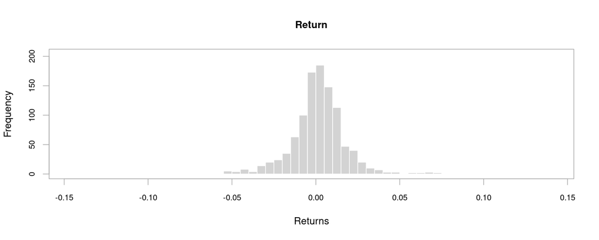

```r
library(PerformanceAnalytics)
MSFT$Return = MSFT$MSFT.Adjusted/lag.xts(MSFT$MSFT.Adjusted,k=1) - 1 # use lag.xts to obtain the lag for xts data
chart.Histogram(MSFT$Return)
```

### Hist. with Density Overlay

```r
rm(list=ls()) # clear workspace
cat("\014")  # clear console
```

```r
library("tidyquant")
ticker = 'MSFT' # asset ticker
start_date = '2017-01-01' # data start date
end_date = '2021-03-01' # data end date
data_src = 'yahoo' # data source
getSymbols(ticker,from = start_date,to = end_date, src=data_src)
```

```
## [1] "MSFT"
```

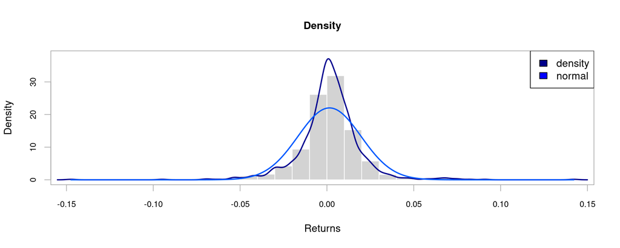

```r
library(PerformanceAnalytics)
MSFT$Return = MSFT$MSFT.Adjusted/lag.xts(MSFT$MSFT.Adjusted,k=1) - 1 # use lag.xts to obtain the lag for xts data
chart.Histogram(MSFT$Return, main = "Density", breaks=40,methods = c("add.density", "add.normal"))
legend("topright", c("density", "normal"), fill=c("blue4", "blue"))
```

### Histogram with VaR

```r
rm(list=ls()) # clear workspace
cat("\014")  # clear console
```

```r
library("tidyquant")
ticker = 'MSFT' # asset ticker
start_date = '2017-01-01' # data start date
end_date = '2021-03-01' # data end date
data_src = 'yahoo' # data source
getSymbols(ticker,from = start_date,to = end_date, src=data_src)
```

```
## [1] "MSFT"
```

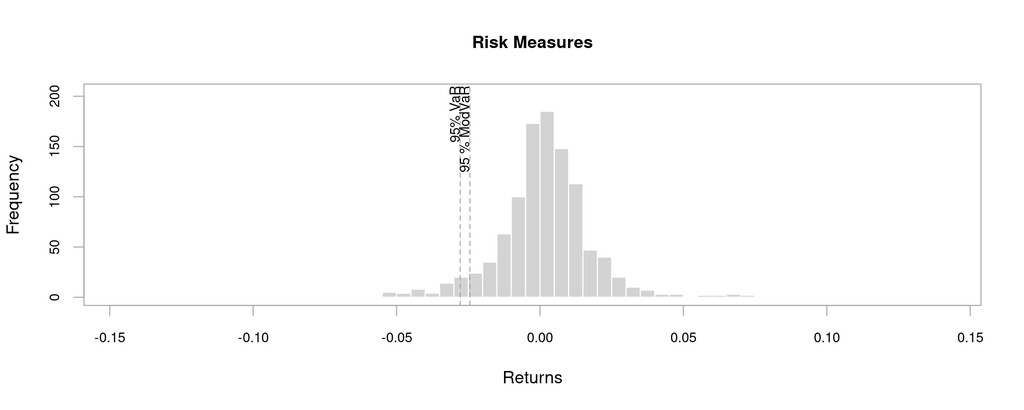

```r
library(PerformanceAnalytics)
MSFT$Return = MSFT$MSFT.Adjusted/lag.xts(MSFT$MSFT.Adjusted,k=1) - 1 # use lag.xts to obtain the lag for xts data
chart.Histogram(MSFT$Return, main = "Risk Measures", methods = c("add.risk"))
```

### Hist. with Risk Boundaries

```r
rm(list=ls()) # clear workspace
cat("\014")  # clear console
```

```r
library("tidyquant")
ticker = 'MSFT' # asset ticker
start_date = '2017-01-01' # data start date
end_date = '2021-03-01' # data end date
data_src = 'yahoo' # data source
getSymbols(ticker,from = start_date,to = end_date, src=data_src)
```

```
## [1] "MSFT"
```

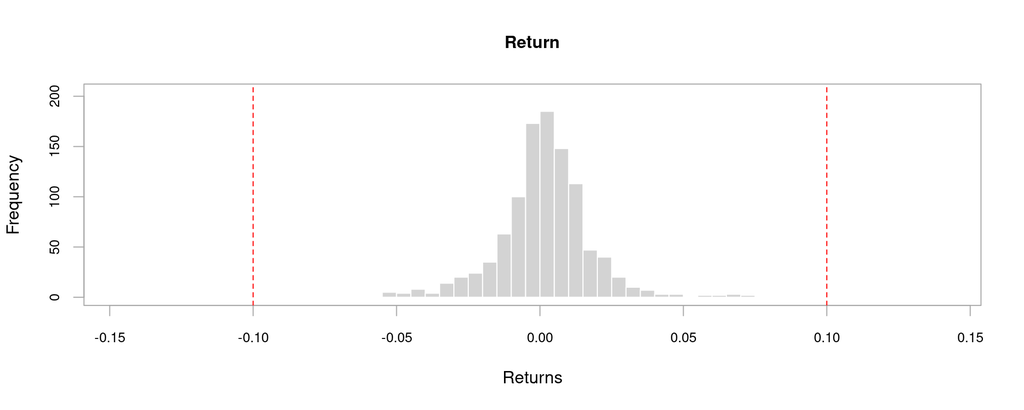

```r
library(PerformanceAnalytics)
MSFT$Return = MSFT$MSFT.Adjusted/lag.xts(MSFT$MSFT.Adjusted,k=1) - 1 # use lag.xts to obtain the lag for xts data
chart.Histogram(MSFT$Return,breaks=100)
threshold = .1
abline(v=-threshold, col="red",lty="dashed")
abline(v=threshold,  col="red",lty="dashed")
```

### Relative Freq. Hist.

```r
rm(list=ls()) # clear workspace
cat("\014")  # clear console
```

```r
library("tidyquant")
library("HistogramTools")
ticker = 'MSFT' # asset ticker
start_date = '2017-01-01' # data start date
end_date = '2021-03-01' # data end date
data_src = 'yahoo' # data source
getSymbols(ticker,from = start_date,to = end_date, src=data_src)
```

```
## [1] "MSFT"
```

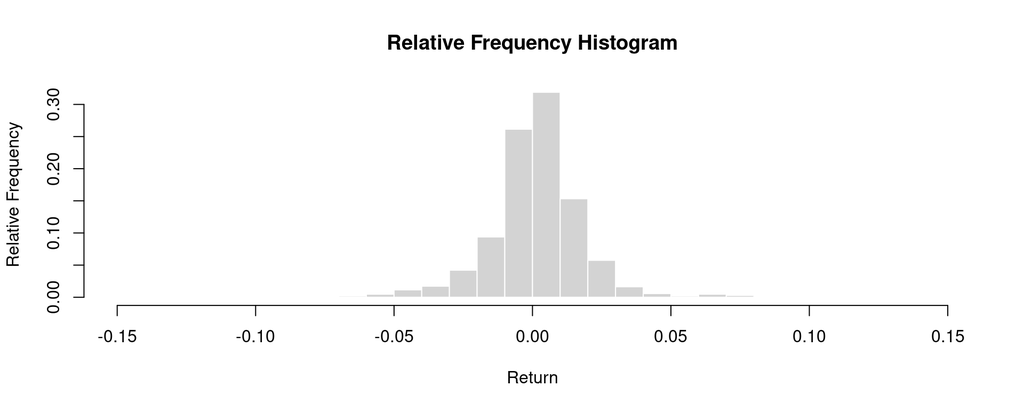

```r
library(PerformanceAnalytics)
MSFT$Return = MSFT$MSFT.Adjusted/lag.xts(MSFT$MSFT.Adjusted,k=1) - 1 # use lag.xts to obtain the lag for xts data
PlotRelativeFrequency(hist(na.omit(MSFT$Return),breaks = 40,plot=FALSE),xlab="Return",main="Relative Frequency Histogram",col = "lightgray",border = "white", )
```

### Order Rank

```r
rm(list=ls()) # clear workspace
cat("\014")  # clear console
```

```r
library("tidyquant")
library("HistogramTools")
ticker = 'MSFT' # asset ticker
start_date = '2017-01-01' # data start date
end_date = '2021-03-01' # data end date
data_src = 'yahoo' # data source
getSymbols(ticker,from = start_date,to = end_date, src=data_src)
```

```
## [1] "MSFT"
```

```r
library(PerformanceAnalytics)
MSFT$Return = MSFT$MSFT.Adjusted/lag.xts(MSFT$MSFT.Adjusted,k=1) - 1 # use lag.xts to obtain the lag for xts data
MSFT$Return.Rank = rank(-as.numeric(MSFT$Return),na.last = "keep")
head(cbind(MSFT$Return,MSFT$Return.Rank))
```

```
##                   Return Return.Rank
## 2017-01-03            NA          NA
## 2017-01-04 -0.0044743126         745
## 2017-01-05  0.0000000000         594
## 2017-01-06  0.0086677509         285
## 2017-01-09 -0.0031826532         711
## 2017-01-10 -0.0003192471         608
```

### Quantiles Historical Ret.

Quantile determines how many values in a distribution are above or below a certain limit, so it is important for performance analysis.

```r
rm(list=ls()) # clear workspace
cat("\014")  # clear console
```

```r
library("tidyquant")
library("HistogramTools")
ticker = 'MSFT' # asset ticker
start_date = '2017-01-01' # data start date
end_date = '2021-03-01' # data end date
data_src = 'yahoo' # data source
getSymbols(ticker,from = start_date,to = end_date, src=data_src)
```

```
## [1] "MSFT"
```

```r
library(PerformanceAnalytics)
MSFT$Return = MSFT$MSFT.Adjusted/lag.xts(MSFT$MSFT.Adjusted,k=1) - 1 # use lag.xts to obtain the lag for xts data
Quantile = quantile(MSFT$Return,probs=seq(0,1,by=0.01),na.rm=TRUE)
print(Quantile[c(1:7,95:101)])
```

```
##          0%          1%          2%          3%          4%          5%
## -0.14739028 -0.04885809 -0.04016764 -0.03185871 -0.02954024 -0.02781349
##          6%         94%         95%         96%         97%         98%
## -0.02437206  0.02428270  0.02583960  0.02848769  0.03296676  0.03736699
##         99%        100%
##  0.06078518  0.14216912
```

### Find Date of Quantile

What is the date of the 80th percentile observation?

```r
rm(list=ls()) # clear workspace
cat("\014")  # clear console
```

```r
library("tidyquant")
library("HistogramTools")
ticker = 'MSFT' # asset ticker
start_date = '2017-01-01' # data start date
end_date = '2021-03-01' # data end date
data_src = 'yahoo' # data source
getSymbols(ticker,from = start_date,to = end_date, src=data_src)
```

```
## [1] "MSFT"
```

```r
library(PerformanceAnalytics)
MSFT$Return = MSFT$MSFT.Adjusted/lag.xts(MSFT$MSFT.Adjusted,k=1) - 1 # use lag.xts to obtain the lag for xts data
# calculate 80th percentage quantile return
Quantile80 = quantile(MSFT$Return,probs=0.8,na.rm=TRUE)
# find the data index with closest return to Quantile80
index80 = which.min(abs(Quantile80-MSFT$Return))
cat(paste("\n\nThe 80th percentile price:",Quantile80,"\nThe date found is:",index(MSFT)[index80],"\nThat day's return is:",MSFT$Return[index80]))
```

```
##
##
## The 80th percentile price: 0.0117882769988489
## The date found is: 2019-11-08
## That day's return is: 0.0117844597094341
```

### Percentile of Obs. on Date

What is the percentile of the observation on Mar.10, 2020?

```r
rm(list=ls()) # clear workspace
cat("\014")  # clear console
```

```r
library("tidyquant")
library("HistogramTools")
ticker = 'MSFT' # asset ticker
start_date = '2017-01-01' # data start date
end_date = '2021-03-01' # data end date
data_src = 'yahoo' # data source
getSymbols(ticker,from = start_date,to = end_date, src=data_src)
```

```
## [1] "MSFT"
```

```r
library(PerformanceAnalytics)
MSFT$Return = MSFT$MSFT.Adjusted/lag.xts(MSFT$MSFT.Adjusted,k=1) - 1 # use lag.xts to obtain the lag for xts data
TargetReturn = MSFT$Return["2020-03-10"]
# calculate its quantile
{EstimatedQuantile =
  sum(na.omit(MSFT$Return)<as.numeric(TargetReturn))/length(na.omit(MSFT$Return))}
cat(paste("\n\nThe return on Mar 10 2020:",TargetReturn,"\nThe estimated quantile :",EstimatedQuantile))
```

```
##
##
## The return on Mar 10 2020: 0.068384105565332
## The estimated quantile : 0.993295019157088
```

### Visualize Outliers

This is a simple heuristic, not a formal rule. Your initial EDA can control the threshold you choose to set.

```r
rm(list=ls()) # clear workspace
cat("\014")  # clear console
```

```r
library("tidyquant")
library("HistogramTools")
ticker = 'MSFT' # asset ticker
start_date = '2017-01-01' # data start date
end_date = '2021-03-01' # data end date
data_src = 'yahoo' # data source
getSymbols(ticker,from = start_date,to = end_date, src=data_src)
```

```
## [1] "MSFT"
```

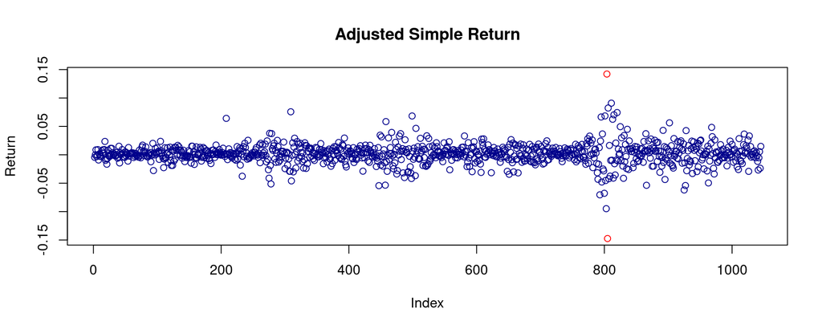

```r
library(PerformanceAnalytics)
MSFT$Return = MSFT$MSFT.Adjusted/lag.xts(MSFT$MSFT.Adjusted,k=1) - 1 # use lag.xts to obtain the lag for xts data
threshold = .1 # use your discretion in setting this
plot(x=1:length(MSFT$Return),y=MSFT$Return,xlab="Index",ylab = "Return",main="Adjusted Simple Return",col=ifelse(abs(MSFT$Return) >= threshold, "red", "darkblue"))
```

### Boxplot of Outliers

```r
rm(list=ls()) # clear workspace
cat("\014")  # clear console
```

```r
library("tidyquant")
ticker = 'MSFT' # asset ticker
start_date = '2017-01-01' # data start date
end_date = '2021-03-01' # data end date
data_src = 'yahoo' # data source
getSymbols(ticker,from = start_date,to = end_date, src=data_src)
```

```
## [1] "MSFT"
```

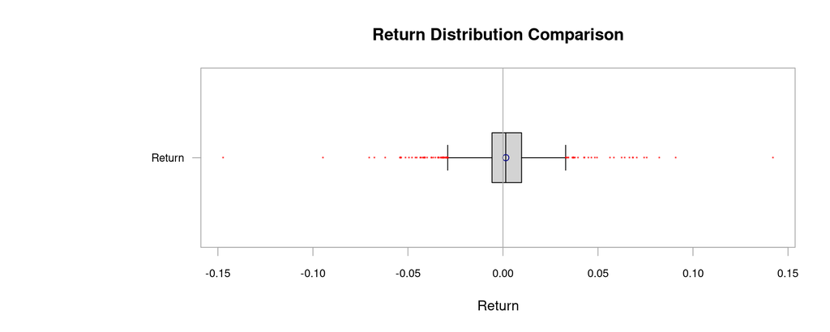

```r
library(PerformanceAnalytics)
MSFT$Return = MSFT$MSFT.Adjusted/lag.xts(MSFT$MSFT.Adjusted,k=1) - 1 # use lag.xts to obtain the lag for xts data
chart.Boxplot(MSFT$Return,outlier.symbol="*",symbol.color =c("darkblue"),outcol="red")
```

### Compute Z Scores

```r
rm(list=ls()) # clear workspace
cat("\014")  # clear console
```

```r
library("tidyquant")
ticker = 'MSFT' # asset ticker
start_date = '2017-01-01' # data start date
end_date = '2021-03-01' # data end date
data_src = 'yahoo' # data source
getSymbols(ticker,from = start_date,to = end_date, src=data_src)
```

```
## [1] "MSFT"
```

```r
library(PerformanceAnalytics)
MSFT$Return = MSFT$MSFT.Adjusted/lag.xts(MSFT$MSFT.Adjusted,k=1) - 1 # use lag.xts to obtain the lag for xts data
# calculate z-scores
MSFT = na.omit(MSFT)
MSFT$Return.Zscore = (MSFT$Return-mean(MSFT$Return))/sd(MSFT$Return)
head(MSFT$Return.Zscore)
```

```
##            Return.Zscore
## 2017-01-04   -0.32910014
## 2017-01-05   -0.08202641
## 2017-01-06    0.39661365
## 2017-01-09   -0.25777611
## 2017-01-10   -0.09966225
## 2017-01-11    0.42063280
```

### DeMean

```r
rm(list=ls()) # clear workspace
cat("\014")  # clear console
```

```r
library("tidyquant")
ticker = 'MSFT' # asset ticker
start_date = '2017-01-01' # data start date
end_date = '2021-03-01' # data end date
data_src = 'yahoo' # data source
getSymbols(ticker,from = start_date,to = end_date, src=data_src)
```

```
## [1] "MSFT"
```

```r
library(PerformanceAnalytics)
MSFT$Return<-MSFT$MSFT.Adjusted/lag.xts(MSFT$MSFT.Adjusted,k=1) - 1 # use lag.xts to obtain the lag for xts data
MSFT = na.omit(MSFT)
MSFT$ReturnDeMean<-MSFT$Return-mean(MSFT$Return)
todisplay<-cbind(MSFT$Return,MSFT$ReturnDeMean)
head(todisplay)
```

```
##                   Return ReturnDeMean
## 2017-01-04 -0.0044743812 -0.005959799
## 2017-01-05  0.0000000000 -0.001485417
## 2017-01-06  0.0086676817  0.007182264
## 2017-01-09 -0.0031825162 -0.004667934
## 2017-01-10 -0.0003193159 -0.001804733
## 2017-01-11  0.0091026089  0.007617192
```

### ReScale

```r
rm(list=ls()) # clear workspace
cat("\014")  # clear console
```

```r
library("tidyquant")
ticker = 'MSFT' # asset ticker
start_date = '2017-01-01' # data start date
end_date = '2021-03-01' # data end date
data_src = 'yahoo' # data source
getSymbols(ticker,from = start_date,to = end_date, src=data_src)
```

```
## [1] "MSFT"
```

```r
upper = 1
lower = 0
MSFT$Return<-MSFT$MSFT.Adjusted/lag.xts(MSFT$MSFT.Adjusted,k=1) - 1 # use lag.xts to obtain the lag for xts data
MSFT = na.omit(MSFT)
MSFT$ReScaledReturn = lower+(MSFT$Return-min(MSFT$Return)*(upper-lower))/(max(MSFT$Return-min(MSFT$Return)))
#MSFT$ReScaledPrice = lower+(MSFT$MSFT.Adjusted-min(MSFT$MSFT.Adjusted)*(upper-lower))/(max(MSFT$MSFT.Adjusted-min(MSFT$MSFT.Adjusted)))
head(MSFT)
```

```
##            MSFT.Open MSFT.High MSFT.Low MSFT.Close MSFT.Volume MSFT.Adjusted
## 2017-01-04     62.48     62.75    62.12      62.30    21340000      57.80565
## 2017-01-05     62.19     62.66    62.03      62.30    24876000      57.80565
## 2017-01-06     62.30     63.15    62.04      62.84    19922900      58.30671
## 2017-01-09     62.76     63.08    62.54      62.64    20382700      58.12112
## 2017-01-10     62.73     63.07    62.28      62.62    18593000      58.10257
## 2017-01-11     62.61     63.23    62.43      63.19    21517300      58.63145
##                   Return ReScaledReturn
## 2017-01-04 -0.0044743300      0.4935643
## 2017-01-05  0.0000000000      0.5090165
## 2017-01-06  0.0086679418      0.5389514
## 2017-01-09 -0.0031828415      0.4980245
## 2017-01-10 -0.0003191783      0.5079142
## 2017-01-11  0.0091024196      0.5404519
```

### Compute IQR

```r
rm(list=ls()) # clear workspace
cat("\014")  # clear console
```

```r
library("tidyquant")
ticker = 'MSFT' # asset ticker
start_date = '2017-01-01' # data start date
end_date = '2021-03-01' # data end date
data_src = 'yahoo' # data source
getSymbols(ticker,from = start_date,to = end_date, src=data_src)
```

```
## [1] "MSFT"
```

```r
library(PerformanceAnalytics)
MSFT$Return = MSFT$MSFT.Adjusted/lag.xts(MSFT$MSFT.Adjusted,k=1) - 1 # use lag.xts to obtain the lag for xts data
# calculate z-scores
MSFT = na.omit(MSFT)
# calculate IQR for history returns
Q3=quantile(MSFT$Return,probs = 0.75)
Q1=quantile(MSFT$Return,probs = 0.25)
IQR = Q3 - Q1
IQR
```

```
##       75%
## 0.0155001
```

```r
# pick observations beyond 2*IQR from the Q1 and Q3
IQR_threshold = 2
IQR_outlier_ind =  which(MSFT$Return>Q3+IQR_threshold*IQR|MSFT$Return<Q1-IQR_threshold*IQR)
# print outliers
print(MSFT$Return[IQR_outlier_ind])
```

```
##                 Return
## 2017-10-27  0.06411897
## 2017-12-04 -0.03774027
## 2018-02-05 -0.04118556
## 2018-02-08 -0.05133365
## 2018-03-26  0.07570548
## 2018-03-27 -0.04595880
## 2018-10-10 -0.05433811
## 2018-10-24 -0.05346912
## 2018-10-25  0.05844428
## 2018-12-07 -0.04002188
## 2018-12-24 -0.04173873
## 2018-12-26  0.06830970
## 2019-01-03 -0.03678793
## 2019-01-04  0.04650917
## 2020-02-24 -0.04311556
## 2020-02-27 -0.07045895
## 2020-03-02  0.06653896
## 2020-03-03 -0.04791953
## 2020-03-09 -0.06777255
## 2020-03-10  0.06838400
## 2020-03-11 -0.04530192
## 2020-03-12 -0.09483820
## 2020-03-13  0.14216876
## 2020-03-16 -0.14739049
## 2020-03-17  0.08233671
## 2020-03-18 -0.04209591
## 2020-03-20 -0.03755872
## 2020-03-24  0.09089579
## 2020-03-26  0.06255107
## 2020-03-27 -0.04106081
## 2020-03-30  0.07034066
## 2020-04-06  0.07436780
## 2020-04-14  0.04948348
## 2020-04-21 -0.04135713
## 2020-04-29  0.04487384
## 2020-06-11 -0.05369837
## 2020-07-20  0.04298115
## 2020-07-23 -0.04349457
## 2020-08-03  0.05624121
## 2020-09-03 -0.06194681
## 2020-09-08 -0.05409567
## 2020-09-09  0.04258361
## 2020-10-28 -0.04956633
## 2020-11-04  0.04824879
```

### Drop Outliers

```r
rm(list=ls()) # clear workspace
cat("\014")  # clear console
```

```r
library("tidyquant")
ticker = 'MSFT' # asset ticker
start_date = '2017-01-01' # data start date
end_date = '2021-03-01' # data end date
data_src = 'yahoo' # data source
getSymbols(ticker,from = start_date,to = end_date, src=data_src)
```

```
## [1] "MSFT"
```

```r
library(PerformanceAnalytics)
MSFT$Return = MSFT$MSFT.Adjusted/lag.xts(MSFT$MSFT.Adjusted,k=1) - 1 # use lag.xts to obtain the lag for xts data
# calculate z-scores
MSFT = na.omit(MSFT)
# calculate IQR for history returns
Q3=quantile(MSFT$Return,probs = 0.75)
Q1=quantile(MSFT$Return,probs = 0.25)
IQR = Q3 - Q1
# pick observations beyond 2*IQR from the Q1 and Q3
IQR_threshold = 2
IQR_outlier_ind =  which(MSFT$Return>Q3+IQR_threshold*IQR|MSFT$Return<Q1-IQR_threshold*IQR)
clean_MSFT = MSFT[-IQR_outlier_ind]
```

### Replace Outliers with Mean

```r
rm(list=ls()) # clear workspace
cat("\014")  # clear console
```

```r
library("tidyquant")
ticker = 'MSFT' # asset ticker
start_date = '2017-01-01' # data start date
end_date = '2021-03-01' # data end date
data_src = 'yahoo' # data source
getSymbols(ticker,from = start_date,to = end_date, src=data_src)
```

```
## [1] "MSFT"
```

```r
library(PerformanceAnalytics)
MSFT$Return = MSFT$MSFT.Adjusted/lag.xts(MSFT$MSFT.Adjusted,k=1) - 1 # use lag.xts to obtain the lag for xts data
# calculate z-scores
MSFT = na.omit(MSFT)
# calculate IQR for history returns
Q3=quantile(MSFT$Return,probs = 0.75)
Q1=quantile(MSFT$Return,probs = 0.25)
IQR = Q3 - Q1
# pick observations beyond 2*IQR from the Q1 and Q3
IQR_threshold = 2
IQR_outlier_ind =  which(MSFT$Return>Q3+IQR_threshold*IQR|MSFT$Return<Q1-IQR_threshold*IQR)
MSFT$CleanReturn= MSFT$Return
newind = c(207,232)
MSFT$CleanReturn[IQR_outlier_ind]<-mean(MSFT$Return)
head(MSFT[IQR_outlier_ind])
```

```
##            MSFT.Open MSFT.High MSFT.Low MSFT.Close MSFT.Volume MSFT.Adjusted
## 2017-10-27     84.37     86.20    83.61      83.81    71066700      79.10302
## 2017-12-04     84.42     84.43    80.70      81.08    39094900      76.91066
## 2018-02-05     90.56     93.24    88.00      88.00    51031500      83.47483
## 2018-02-08     89.71     89.88    84.76      85.01    55628700      80.63857
## 2018-03-26     90.61     94.00    90.40      93.78    56396800      89.37547
## 2018-03-27     94.94     95.14    88.51      89.47    56569000      85.26789
##                 Return CleanReturn
## 2017-10-27  0.06411908 0.001485417
## 2017-12-04 -0.03774046 0.001485417
## 2018-02-05 -0.04118520 0.001485417
## 2018-02-08 -0.05133364 0.001485417
## 2018-03-26  0.07570539 0.001485417
## 2018-03-27 -0.04595863 0.001485417
```

### Replace Outliers with Quant.

```r
rm(list=ls()) # clear workspace
cat("\014")  # clear console
```

```r
library("tidyquant")
ticker = 'MSFT' # asset ticker
start_date = '2017-01-01' # data start date
end_date = '2021-03-01' # data end date
data_src = 'yahoo' # data source
getSymbols(ticker,from = start_date,to = end_date, src=data_src)
```

```
## [1] "MSFT"
```

```r
library(PerformanceAnalytics)
MSFT$Return = MSFT$MSFT.Adjusted/lag.xts(MSFT$MSFT.Adjusted,k=1) - 1 # use lag.xts to obtain the lag for xts data
# calculate z-scores
MSFT = na.omit(MSFT)
# calculate IQR for history returns
Q3=quantile(MSFT$Return,probs = 0.75)
Q1=quantile(MSFT$Return,probs = 0.25)
IQR = Q3 - Q1
# pick observations beyond 2*IQR from the Q1 and Q3
IQR_threshold = 2
IQR_outlier_ind =  which(MSFT$Return>Q3+IQR_threshold*IQR|MSFT$Return<Q1-IQR_threshold*IQR)
trimfun <- function(x){
    quantiles <- quantile( x, c(.25, .75 ) )
    x[ x < quantiles[1] ] <- quantiles[1]
    x[ x > quantiles[2] ] <- quantiles[2]
    x
}
MSFT$CleanReturn = trimfun(MSFT$Return)
```

### Rolling Mean Return

```r
rm(list=ls()) # clear workspace
cat("\014")  # clear console
```

```r
library("tidyquant")
ticker = 'MSFT' # asset ticker
start_date = '2017-01-01' # data start date
end_date = '2021-03-01' # data end date
data_src = 'yahoo' # data source
getSymbols(ticker,from = start_date,to = end_date, src=data_src)
```

```
## [1] "MSFT"
```

```r
library(PerformanceAnalytics)
MSFT$Return = MSFT$MSFT.Adjusted/lag.xts(MSFT$MSFT.Adjusted,k=1) - 1 # use lag.xts to obtain the lag for xts data
# calculate z-scores
MSFT = na.omit(MSFT)
library(PerformanceAnalytics)
width_n = 250 # window length = 1 year
by_n = 1 # update(recalculate) frequency = everyday
MSFT$RollingReturn250D = apply.rolling(MSFT$Return, width = width_n, by = by_n,FUN="mean")
tail(cbind(MSFT$Return,MSFT$RollingReturn250D))
```

```
##                  Return RollingReturn250D
## 2021-02-19 -0.011567314       0.001796962
## 2021-02-22 -0.026808318       0.001755736
## 2021-02-23 -0.005287555       0.001684606
## 2021-02-24  0.005487186       0.001988392
## 2021-02-25 -0.023704960       0.001796719
## 2021-02-26  0.014804073       0.001589779
```

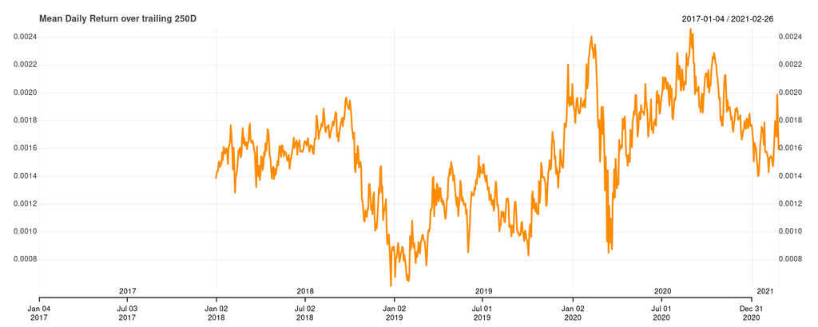

```r
chart_Series(MSFT$RollingReturn250D, name = "Mean Daily Return over trailing 250D")
```

### Rolling Std of Returns

```r
rm(list=ls()) # clear workspace
cat("\014")  # clear console
```

```r
library("tidyquant")
ticker = 'MSFT' # asset ticker
start_date = '2017-01-01' # data start date
end_date = '2021-03-01' # data end date
data_src = 'yahoo' # data source
getSymbols(ticker,from = start_date,to = end_date, src=data_src)
```

```
## [1] "MSFT"
```

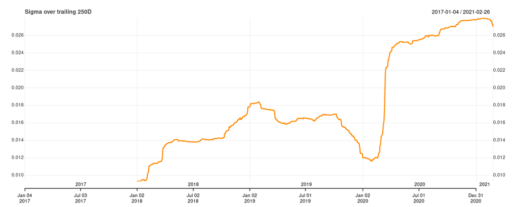

```r
library(PerformanceAnalytics)
MSFT$Return = MSFT$MSFT.Adjusted/lag.xts(MSFT$MSFT.Adjusted,k=1) - 1 # use lag.xts to obtain the lag for xts data
# calculate z-scores
MSFT = na.omit(MSFT)
library(PerformanceAnalytics)
width_n = 250 # window length = 1 year
by_n = 1 # update(recalculate) frequency = everyday
MSFT$RollingSD = apply.rolling(MSFT$Return, width = width_n, by = by_n,FUN="sd")
chart_Series(MSFT$RollingSD, name = "Sigma over trailing 250D")
```

### Rolling Skewness of Returns

```r
rm(list=ls()) # clear workspace
cat("\014")  # clear console
```

```r
library("tidyquant")
ticker = 'MSFT' # asset ticker
start_date = '2017-01-01' # data start date
end_date = '2021-03-01' # data end date
data_src = 'yahoo' # data source
getSymbols(ticker,from = start_date,to = end_date, src=data_src)
```

```
## [1] "MSFT"
```

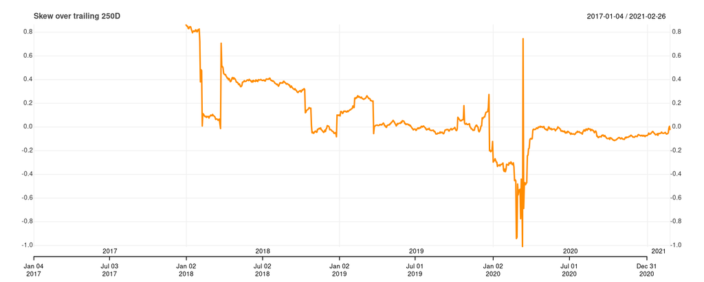

```r
library(PerformanceAnalytics)
MSFT$Return = MSFT$MSFT.Adjusted/lag.xts(MSFT$MSFT.Adjusted,k=1) - 1 # use lag.xts to obtain the lag for xts data
# calculate z-scores
MSFT = na.omit(MSFT)
library(PerformanceAnalytics)
width_n = 250 # window length = 1 year
by_n = 1 # update(recalculate) frequency = everyday
MSFT$RollingSkew = apply.rolling(MSFT$Return, width = width_n, by = by_n,FUN="skewness")
chart_Series(MSFT$RollingSkew, name = "Skew over trailing 250D")
```

### Rolling Kurtosis of Returns

```r
rm(list=ls()) # clear workspace
cat("\014")  # clear console
```

```r
library("tidyquant")
ticker = 'MSFT' # asset ticker
start_date = '2017-01-01' # data start date
end_date = '2021-03-01' # data end date
data_src = 'yahoo' # data source
getSymbols(ticker,from = start_date,to = end_date, src=data_src)
```

```
## [1] "MSFT"
```

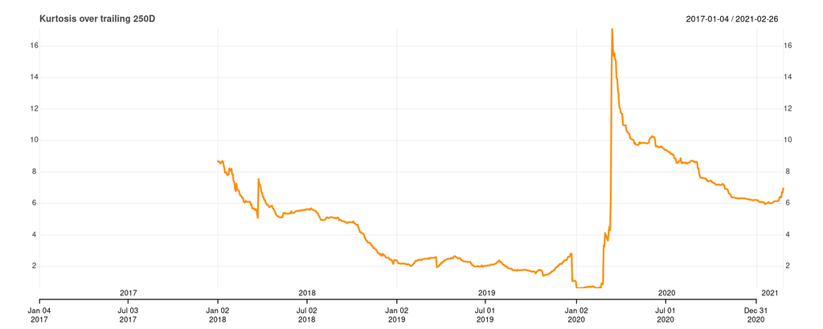

```r
library(PerformanceAnalytics)
MSFT$Return = MSFT$MSFT.Adjusted/lag.xts(MSFT$MSFT.Adjusted,k=1) - 1 # use lag.xts to obtain the lag for xts data
# calculate z-scores
MSFT = na.omit(MSFT)
library(PerformanceAnalytics)
width_n = 250 # window length = 1 year
by_n = 1 # update(recalculate) frequency = everyday
MSFT$RollingKurt = apply.rolling(MSFT$Return, width = width_n, by = by_n,FUN="kurtosis")
chart_Series(MSFT$RollingKurt, name = "Kurtosis over trailing 250D")
```

### Rolling Total Return

```r
rm(list=ls()) # clear workspace
cat("\014")  # clear console
```

```r
library("tidyquant")
ticker = 'MSFT' # asset ticker
start_date = '2017-01-01' # data start date
end_date = '2021-03-01' # data end date
data_src = 'yahoo' # data source
getSymbols(ticker,from = start_date,to = end_date, src=data_src)
```

```
## [1] "MSFT"
```

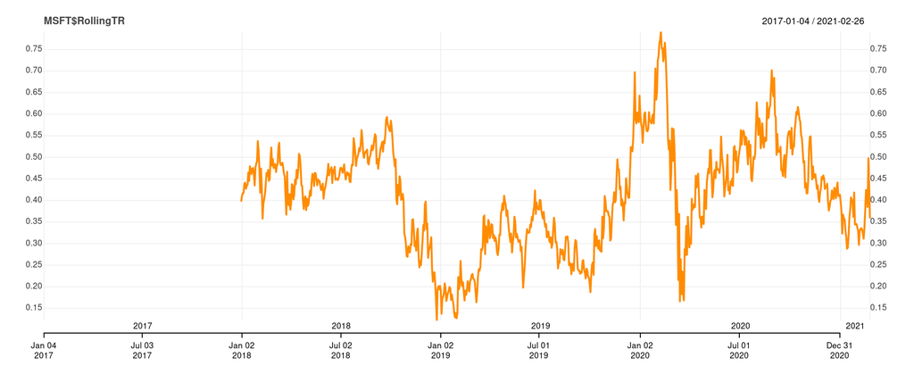

```r
library(PerformanceAnalytics)
MSFT$Return = MSFT$MSFT.Adjusted/lag.xts(MSFT$MSFT.Adjusted,k=1) - 1 # use lag.xts to obtain the lag for xts data
# calculate z-scores
MSFT = na.omit(MSFT)
library(PerformanceAnalytics)
width_n = 250 # window length
by_n = 1 # update(recalculate) frequency = everyday
MSFT$GrossReturn<-MSFT$Return+1
MSFT$RollingTR = apply.rolling(MSFT$GrossReturn, width = width_n, by = by_n,FUN="prod")-1
chart_Series(MSFT$RollingTR)
```

### Create Calendar Dummies

```r
rm(list=ls()) # clear workspace
cat("\014")  # clear console
```

```r
library("tidyquant")
ticker = 'MSFT' # asset ticker
start_date = '2017-01-01' # data start date
end_date = '2021-03-01' # data end date
data_src = 'yahoo' # data source
getSymbols(ticker,from = start_date,to = end_date, src=data_src)
```

```
## [1] "MSFT"
```

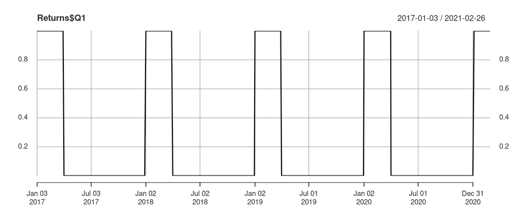

```r
Returns = periodReturn(MSFT$MSFT.Adjusted,period = 'daily',type = 'log')
library(lubridate)
Returns$Q1<-ifelse(quarter(index(Returns))==1,1,0)
plot(Returns$Q1)
```

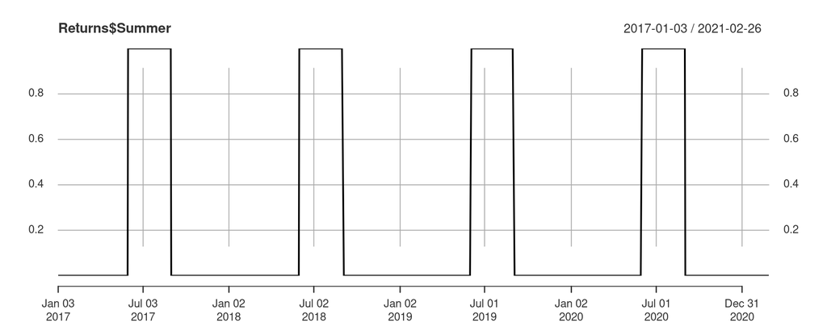

```r
Returns$Summer<- ifelse(month(index(Returns))==6 | month(index(Returns))==7 | month(index(Returns))==8,1,0)
plot(Returns$Summer)
```

### Create Dummies by Value

```r
rm(list=ls()) # clear workspace
cat("\014")  # clear console
```

```r
library("tidyquant")
ticker = 'MSFT' # asset ticker
start_date = '2017-01-01' # data start date
end_date = '2021-03-01' # data end date
data_src = 'yahoo' # data source
getSymbols(ticker,from = start_date,to = end_date, src=data_src)
```

```
## [1] "MSFT"
```

```r
Returns = periodReturn(MSFT$MSFT.Adjusted,period = 'daily',type = 'log')
colnames(Returns)<-ticker
Quant75=quantile(Returns,.75)
Returns$Big<-ifelse(Returns>Quant75,1,0)
head(Returns[Returns$MSFT>Quant75])
```

```
##                  MSFT Big
## 2017-01-27 0.02322285   1
## 2017-02-09 0.01130300   1
## 2017-02-13 0.01118727   1
## 2017-03-01 0.01489334   1
## 2017-03-22 0.01268993   1
## 2017-04-21 0.01364710   1
```

```r
head(Returns[Returns$MSFT<Quant75])
```

```
##                     MSFT Big
## 2017-01-03  0.0000000000   0
## 2017-01-04 -0.0044841798   0
## 2017-01-05  0.0000000000   0
## 2017-01-06  0.0086304183   0
## 2017-01-09 -0.0031877972   0
## 2017-01-10 -0.0003194874   0
```

### Test Equal Mean Returns

```r
rm(list=ls()) # clear workspace
cat("\014")  # clear console
```

```r
library(PortfolioAnalytics)
data("EuStockMarkets")
Prices<-as.data.frame(EuStockMarkets)
T = dim(Prices)[1]
Returns<-log(Prices[2:T,]/Prices[1:T-1,])
t.test(Returns$DAX,Returns$CAC,var.equal=TRUE)
```

```
##
##  Two Sample t-test
##
## data:  Returns$DAX and Returns$CAC
## t = 0.61417, df = 3716, p-value = 0.5391
## alternative hypothesis: true difference in means is not equal to 0
## 95 percent confidence interval:
##  -0.0004713134  0.0009012890
## sample estimates:
##    mean of x    mean of y
## 0.0006520417 0.0004370540
```

```r
t.test(Returns$DAX,Returns$CAC) # If variances unequal
```

```
##
##  Welch Two Sample t-test
##
## data:  Returns$DAX and Returns$CAC
## t = 0.61417, df = 3698.7, p-value = 0.5391
## alternative hypothesis: true difference in means is not equal to 0
## 95 percent confidence interval:
##  -0.0004713145  0.0009012900
## sample estimates:
##    mean of x    mean of y
## 0.0006520417 0.0004370540
```

### Test Mean Ret. One-Sided

```r
rm(list=ls()) # clear workspace
cat("\014")  # clear console
```

```r
library(PortfolioAnalytics)
data("EuStockMarkets")
Prices<-as.data.frame(EuStockMarkets)
T = dim(Prices)[1]
Returns<-log(Prices[2:T,]/Prices[1:T-1,])
t.test(Returns$DAX,Returns$CAC,var.equal=TRUE,alternative = 'greater')
```

```
##
##  Two Sample t-test
##
## data:  Returns$DAX and Returns$CAC
## t = 0.61417, df = 3716, p-value = 0.2696
## alternative hypothesis: true difference in means is greater than 0
## 95 percent confidence interval:
##  -0.0003609303           Inf
## sample estimates:
##    mean of x    mean of y
## 0.0006520417 0.0004370540
```

### Test Equal Variance Returns

```r
rm(list=ls()) # clear workspace
cat("\014")  # clear console
```

```r
library(PortfolioAnalytics)
data("EuStockMarkets")
Prices<-as.data.frame(EuStockMarkets)
T = dim(Prices)[1]
Returns<-log(Prices[2:T,]/Prices[1:T-1,])
Obs<-index(Returns)
Returns$Obs<-Obs
Returns<-subset(Returns,select=-c(SMI,FTSE))
StackedReturns<-cbind(Returns$Obs,stack(Returns[1:2]))
var.test(values~ind,data=StackedReturns)
```

```
##
##  F test to compare two variances
##
## data:  values by ind
## F = 0.87202, num df = 1858, denom df = 1858, p-value = 0.003178
## alternative hypothesis: true ratio of variances is not equal to 1
## 95 percent confidence interval:
##  0.7961927 0.9550629
## sample estimates:
## ratio of variances
##          0.8720172
```

### Return Correlation

```r
rm(list=ls()) # clear workspace
cat("\014")  # clear console
```

```r
library(quantmod)
Tickers<-c('F','GE','CAT')
startd = "2015-01-01"
endd = "2021-04-30"
TickersReturned<-getSymbols(Tickers,from=startd,to=endd,src='yahoo')
Returns = do.call(merge,lapply(Tickers, function(x)
        periodReturn(Ad(get(x)),period='daily',type='arithmetic')))
Returns = na.omit(Returns[-1,])
colnames(Returns)<-Tickers
ReturnCorMatrix = cor(Returns)
print(ReturnCorMatrix)
```

```
##             F        GE       CAT
## F   1.0000000 0.5160317 0.5337421
## GE  0.5160317 1.0000000 0.4983245
## CAT 0.5337421 0.4983245 1.0000000
```

### Visualize Correlations (v1)

```r
rm(list=ls()) # clear workspace
cat("\014")  # clear console
```

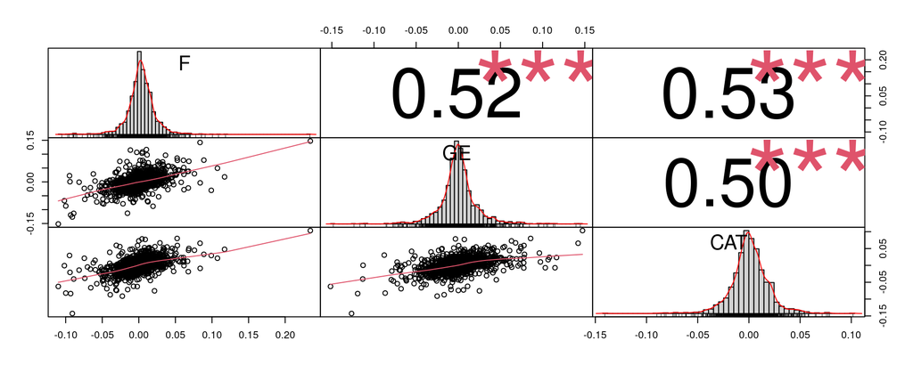

```r
library(quantmod)
library(PerformanceAnalytics)
Tickers<-c('F','GE','CAT')
startd = "2015-01-01"
endd = "2021-04-30"
TickersReturned<-getSymbols(Tickers,from=startd,to=endd,src='yahoo')
Returns = do.call(merge,lapply(Tickers, function(x)
        periodReturn(Ad(get(x)),period='daily',type='arithmetic')))
Returns = na.omit(Returns[-1,])
colnames(Returns)<-Tickers
chart.Correlation(Returns)
```

### Visualize Correlations (v2)

The `corrplot()` function from package allows to draw other fancy correlation graphs(go for this notebook for more examples)

```r
rm(list=ls()) # clear workspace
cat("\014")  # clear console
```

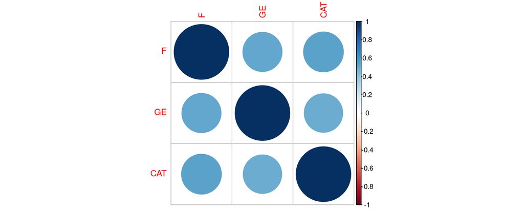

```r
library(quantmod)
library(corrplot)
Tickers<-c('F','GE','CAT')
startd = "2015-01-01"
endd = "2021-04-30"
TickersReturned<-getSymbols(Tickers,from=startd,to=endd,src='yahoo')
Returns = do.call(merge,lapply(Tickers, function(x)
        periodReturn(Ad(get(x)),period='daily',type='arithmetic')))
Returns = na.omit(Returns[-1,])
colnames(Returns)<-Tickers
ReturnCorMatrix = cor(Returns)
corrplot(ReturnCorMatrix, method="circle")
```

### Rolling Correlations

```r
rm(list=ls()) # clear workspace
cat("\014")  # clear console
```

```r
library(quantmod)
library(corrplot)
Tickers<-c('F','GE','CAT')
startd = "2015-01-01"
endd = "2021-04-30"
TickersReturned<-getSymbols(Tickers,from=startd,to=endd,src='yahoo')
Returns = do.call(merge,lapply(Tickers, function(x)
        periodReturn(Ad(get(x)),period='daily',type='arithmetic')))
Returns = na.omit(Returns[-1,])
colnames(Returns)<-Tickers
cor2 <- function(x) cor(x[,1], x[,2])
# correlation of trailing 20day window
RollCorM60D = rollapply(data = Returns[,c("F","GE")], width = 60,FUN=cor2, by.column = FALSE)
names(RollCorM60D) = "60D"
```

### Covariance of Returns

```r
rm(list=ls()) # clear workspace
cat("\014")  # clear console
```

```r
library(quantmod)
library(corrplot)
Tickers<-c('F','GE','CAT')
startd = "2015-01-01"
endd = "2021-04-30"
TickersReturned<-getSymbols(Tickers,from=startd,to=endd,src='yahoo')
Returns = do.call(merge,lapply(Tickers, function(x)
        periodReturn(Ad(get(x)),period='daily',type='arithmetic')))
Returns = na.omit(Returns[-1,])
colnames(Returns)<-Tickers
CovMatrix<-cov(Returns)
CovMatrix
```

```
##                F           GE          CAT
## F   0.0004277847 0.0002526818 0.0002115286
## GE  0.0002526818 0.0005604924 0.0002260591
## CAT 0.0002115286 0.0002260591 0.0003671550
```